# 7 allosteric maps

Aina Martí-Aranda

June 2025

# initializing

```r
base_dir<-"/Users/aa33/Library/CloudStorage/OneDrive-WellcomeSangerInstitute/001-Projects/03-PDZ_Homologs/02-DryLab/001-data_analysis/data_analysis_github/"
knitr::opts_knit$set(root.dir = base_dir)
setwd(base_dir)

# load some variables
load('source_variables.RData')
```

## libraries used for the analysis

```r
library(data.table)
library(ggplot2)
library(dplyr)
library(readxl)
library(tidyr)
library(cowplot)
library(ggpmisc)
library(ggpubr)
library(ggridges)
library(rstatix)
```

# load the data

```r
all_ddg_table<-as.data.table(read.csv(paste0("tmp_tables/all_ddg_table.csv")))
all_median_ddg_table<-as.data.table(read.csv(paste0("tmp_tables/all_median_ddg_table.csv")))
pdb_metrics_dt<-as.data.table(read.csv("data/annotations/structure_metrics.csv", sep=" "))
aln_table<-as.data.table(read.table(paste0("data/annotations/structural_alignment_tcoffee.csv")))
get_contacts_dt<-as.data.table(read.csv("data/annotations/tmp_files/contacts_table_complete.csv", sep=","))
BI_hotspots_dt<-fread(paste0("tmp_tables/BI_hotspots_dt.csv"))
all_allo_table<-as.data.table(read.csv("tmp_tables/allostery_individualCurves_mutationLevel_noBI.csv", sep=" "))
load(paste0("tmp_tables/all_bi.Rdata"))
load(paste0("tmp_tables/core_bi.Rdata"))
load(paste0("tmp_tables/BI_hotspots.Rdata"))
```

# ddG distributions outside of the binding interface:

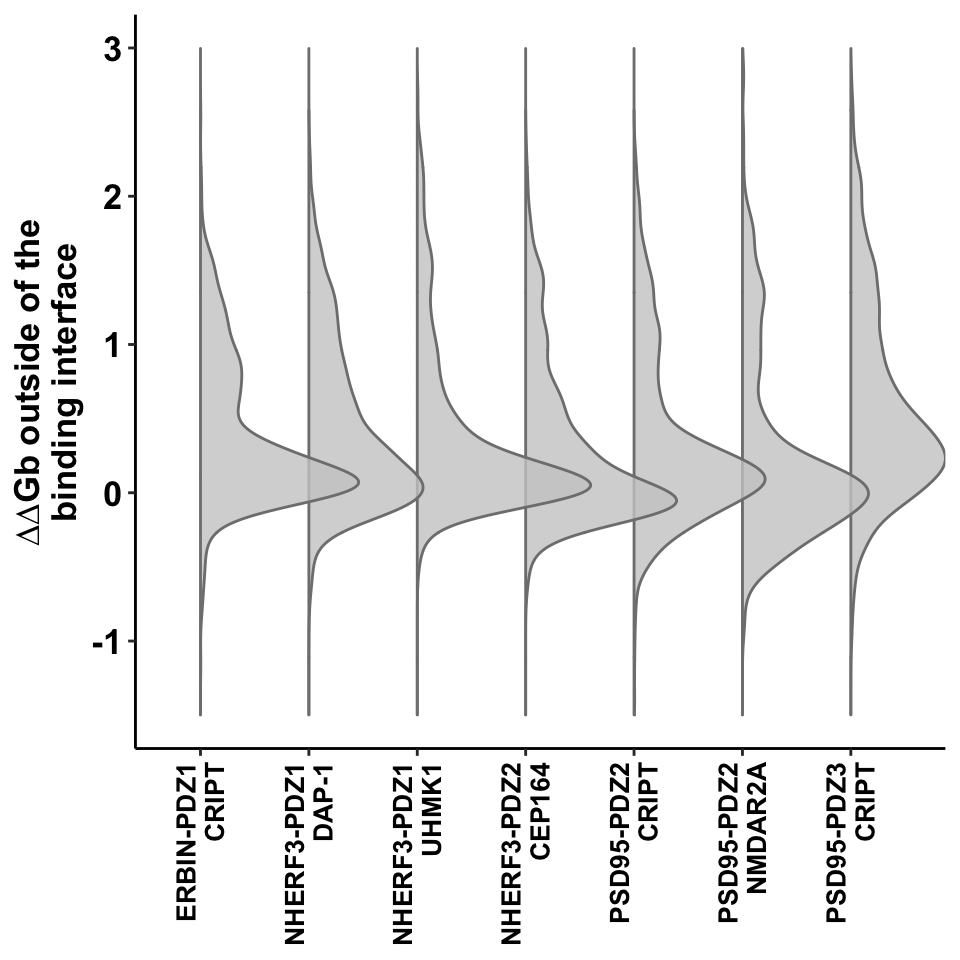

```r
all_ddg_table_binding<-all_ddg_table[assay=="binding"]
all_ddg_table_binding$library_name<-gsub("_", "-", gsub(" binding ", "\n", (unlist(lapply(all_ddg_table_binding$library, lib_code_to_name, libraries_names, libraries_names_plots)))))


ggplot(all_ddg_table_binding[is.na(binding_interface_contacts)], aes(x=ddg))+#!structural_alignment_pos %in% all_bi], aes(x=ddg))+
  theme_classic()+
  xlab("∆∆Gb outside of the\nbinding interface")+
  theme(legend.position = "none",
        axis.title.x=element_blank(),
        axis.text.x=element_text(angle=90, vjust=0.5))+
  xlim(c(-1.5,3))+
  geom_density_ridges2(aes(y=library_name), scale = 1.6, alpha=0.8,fill="grey80", color="grey50")+
  coord_flip()+
  theme(axis.text.x=element_text(hjust=1))+
  theme(axis.text.x=element_text(size=10,face="bold", color="black"),
        axis.text.y=element_text(size=13,face="bold", color="black"),
        axis.title.y=element_text(size=13,face="bold", color="black"),
        axis.title.x=element_blank())
```

```r
ggsave(paste0("Figs/Fig4/Fig4Addg_distributions.pdf"), width=4, height=3.5)
```

# Decay curves in PDZ domains

## d1/2 values in PDZ domains

Plotting absolute ∆∆Gb against the Euclidean distance to the nearest ligand residue reveals a strikingly conserved relationship across all seven interactions: the probability of a mutation causing a change in binding energy decays with the distance from the binding interface, with a 50% reduction of allosteric effects over a median distance d1/2 = 6.9 Å (Fig. 4b,c).

```r
# studying the d1/2 values of these curves
curve_coefficients<-all_allo_table[,.(a=coef_individual_curve_a[1], b=coef_individual_curve_b[1]), by=.(library)]
curve_coefficients[,half_ddg := a / 2 ] # 50% reduction
curve_coefficients[,half_d:=log(half_ddg / a) / b]
summary(curve_coefficients$half_d)
```

```
##    Min. 1st Qu.  Median    Mean 3rd Qu.    Max.
##   5.060   6.260   6.931   6.916   7.603   8.696
```

```r
summary(curve_coefficients$a)
```

```
##    Min. 1st Qu.  Median    Mean 3rd Qu.    Max.
##   1.270   1.300   1.369   1.416   1.501   1.675
```

```r
summary(curve_coefficients$b)
```

```
##     Min.  1st Qu.   Median     Mean  3rd Qu.     Max.
## -0.13700 -0.11076 -0.10001 -0.10299 -0.09133 -0.07971
```

## plot of decay curves in PDZ domains

```r
library(ggnewscale)
library(RColorBrewer)
library(ggh4x)
```

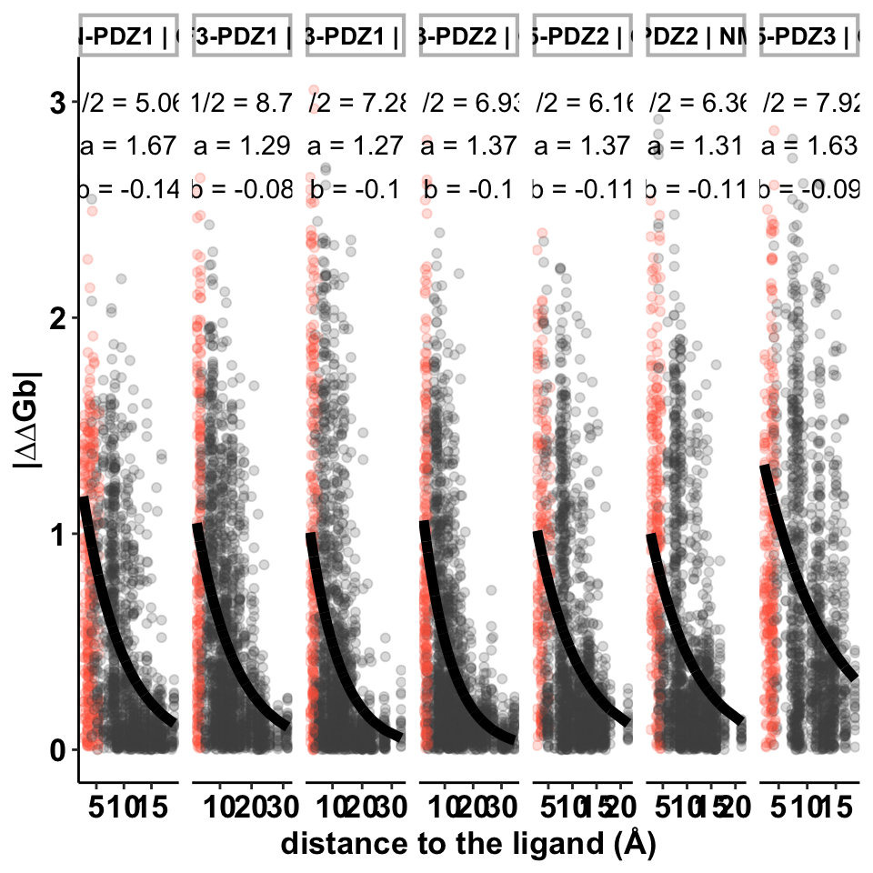

```r
all_allo_table$library_name<-gsub("_", "-", gsub(" binding ", " | ", (unlist(lapply(all_allo_table$library, lib_code_to_name, libraries_names, libraries_names_plots)))))
curve_coefficients$library_name<-gsub("_", "-", gsub(" binding ", " | ", (unlist(lapply(curve_coefficients$library, lib_code_to_name, libraries_names, libraries_names_plots)))))

facet_colors <- setNames(brewer.pal(length(unique(all_allo_table$library_name)), "Set2"), unique(all_allo_table$library_name))

curve_coefficients[, label_half_d:=paste0("d1/2 = ", round(half_d, 2), "Å")]

midpoints <- all_allo_table %>%
  group_by(library_name) %>%
  summarise(midpoint_x = mean(range(scHAmin_ligand)))

curve_coefficients <- curve_coefficients %>%
  left_join(midpoints, by = "library_name")

curve_coefficients[, label_a:=paste0("a = ", round(a, 2))]
curve_coefficients[, label_b:=paste0("b = ", round(b, 2))]

p<-ggplot(all_allo_table, aes(x=scHAmin_ligand, y=ddg))+
  geom_point(alpha=0.2, aes(color=binding_interface_contacts))+
  scale_color_manual(values=c("grey30", "tomato"))+
  new_scale_color()+
  geom_line(aes(x=scHAmin_ligand, y=allo_predicted), color="black", size=2)+
  scale_color_brewer(palette="Set2")+
  facet_grid2(~library_name, strip = strip_themed(
    text_x = elem_list_text(face = "bold", colour = "black")), scale="free_x") +
  theme_classic()+
  theme(legend.position="none",
        strip.text.x = element_text(size = 10, face = "bold"),
        strip.background = element_rect(color="grey", fill="white", size=1.5, linetype="solid"
     ))+
  geom_text(data=curve_coefficients, aes(label=label_half_d, x=midpoint_x, y=3), color="black", font = "bold")+
  geom_text(data=curve_coefficients, aes(label=label_a, x=midpoint_x, y=2.8), color="black", font = "bold")+
  geom_text(data=curve_coefficients, aes(label=label_b, x=midpoint_x, y=2.6), color="black", font = "bold")+
  ylab("|∆∆Gb|")+
  xlab("distance to the ligand (Å)")+
  theme(axis.text.x=element_text(size=13,face="bold", color="black"),
        axis.text.y=element_text(size=13,face="bold", color="black"),
        axis.title.y=element_text(size=13,face="bold", color="black"),
        axis.title.x=element_text(size=13,face="bold", color="black"))
p
```

```r
ggsave(paste0("Figs/Fig4/Fig4Bdecay_curves_pdz.pdf"), width=14, height=3)
curve_coefficients_all_tested<-curve_coefficients[,model:="exclude BI (getContacts)"]
```

# Decay curves in other domains

This decay is similar to that quantified for allostery in the SRC kinase domain23 (d1/2 = 8.3 Å, Extended Data Fig. 4a), KRAS for six interaction partners22 (median d1/2 = 9.50Å, Extended Data Fig. 4b), GB119 (d1/2 = 5.6 Å), and GRB2-SH3 domain19 (d1/2 = 13.6 Å, Extended Data Fig. 4c). This conserved distance-dependent decay of allosteric efficacy in nine different proteins suggests it is a general principle of allosteric communication (Fig. 4c).

## d1/2 values in GRB2 and GB1

```r
andre_ddpca_ddg_dt<-as.data.table(read_xlsx(paste0("data/external_data/Andre_ddPCA_41586_2022_4586_MOESM10_ESM.xlsx"), sheet=2))[id!="-0-"]

all_ddg_table[, Mut:=substr(id, nchar(id), nchar(id))]
all_ddg_table_tmp<-left_join(all_ddg_table[library=="psd95_pdz3_cript"][, Pos_ref:=Uniprot_pos_ref.y][, .(id,Uniprot_pos_ref, ddg, Mut)],andre_ddpca_ddg_dt[protein=="PSD95-PDZ3"][, Uniprot_pos_ref:=as.integer(Pos_ref)], by=c("Uniprot_pos_ref", "Mut"))
```

```r
libraries_andre<-unique(andre_ddpca_ddg_dt$protein)
andre_ddpca_ddg_dt[,abs_ddg:=abs(as.numeric(b_ddg_pred))]
andre_ddpca_ddg_dt[,scHAmin_ligand:=as.numeric(scHAmin_ligand)]
andre_ddpca_ddg_dt[,binding_interface_5A:=Pos_class=="binding_interface"]

half_d_list<-list()
a_list<-list()
b_list<-list()
andre_allo_curves_table<-data.table()
c=1
for (lib in libraries_andre){
    print(paste0("assay: ", lib))
    andre_grb2_ddg_dt_subset<-andre_ddpca_ddg_dt[protein==lib & !is.na(scHAmin_ligand)& !is.na(abs_ddg) & !is.na(scHAmin_ligand) & !is.na(abs_ddg) & b_ddg_pred_conf==T & abs(b_ddg_pred)<2.5]

  xvector_starting=andre_grb2_ddg_dt_subset[protein==lib & !is.na(scHAmin_ligand)& !is.na(abs_ddg) & binding_interface_5A==F & b_ddg_pred_conf==T & !is.na(scHAmin_ligand) & !is.na(abs_ddg)]$scHAmin_ligand
    yvector_starting=abs(as.numeric(andre_grb2_ddg_dt_subset[protein==lib & !is.na(scHAmin_ligand)& !is.na(abs_ddg)& binding_interface_5A==F & b_ddg_pred_conf==T & !is.na(scHAmin_ligand) & !is.na(abs_ddg)]$abs_ddg))

    exponential_curve_fitted<-fit_exponential_curve(xvector=xvector_starting,yvector=yvector_starting,tit,plotfig=F,writepar=FALSE)
    summary(exponential_curve_fitted)
    exponential_estimate<-summary(exponential_curve_fitted)$coefficients[2]

    #this model is a*e**bx
    andre_grb2_ddg_dt_subset[,allo_predicted:=coef(exponential_curve_fitted)[1]*exp(coef(exponential_curve_fitted)[2]*scHAmin_ligand)]
    andre_grb2_ddg_dt_subset[,coef_individual_curve_a:=coef(exponential_curve_fitted)[1]]
    andre_grb2_ddg_dt_subset[,coef_individual_curve_b:=coef(exponential_curve_fitted)[2]]

    a <- coef(exponential_curve_fitted)[1]
    b <- coef(exponential_curve_fitted)[2]

    half_ddg <- a / 2  # 50% reduction
    half_d <- log(half_ddg / a) / b

    print(paste0("HALF DDG: ", half_ddg))
    print(paste0("HALF d: ", half_d))

    andre_grb2_ddg_dt_subset[,half_d:=half_d]
    half_d_list[[c]]<-half_d
    a_list[[c]]<-a
    b_list[[c]]<-b

    c=c+1

    andre_allo_curves_table<-rbind(andre_allo_curves_table, andre_grb2_ddg_dt_subset)
}
```

```
## [1] "assay: GB1"
## [1] 0.06643198
## [1] "HALF DDG: 0.480887386909616"
## [1] "HALF d: 5.66860167976225"
## [1] "assay: PSD95-PDZ3"
## [1] 0.1292646
## [1] "HALF DDG: 0.630212047400747"
## [1] "HALF d: 5.93103271239254"
## [1] "assay: GRB2-SH3"
## [1] 0.03660627
## [1] "HALF DDG: 0.296795602707406"
## [1] "HALF d: 13.6199210489152"
```

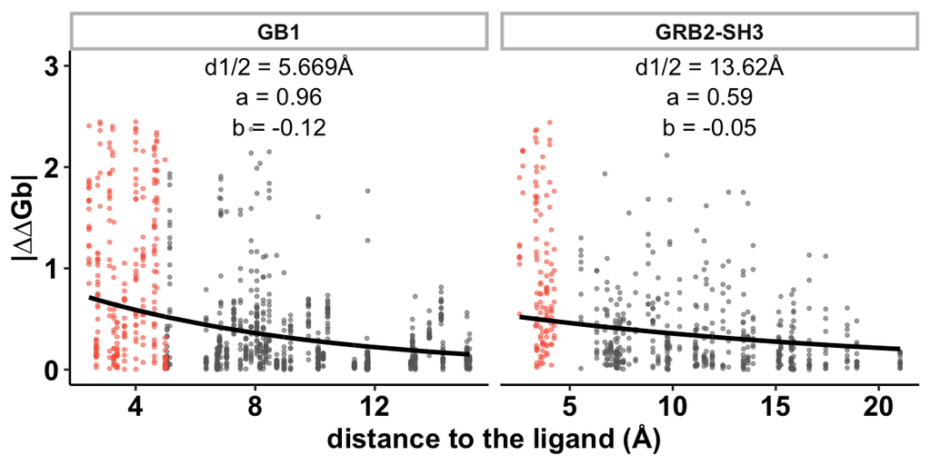

```r
# prepare half d labels
half_d_dt<-data.table(half_d_list)
half_d_dt[, a:=a_list]
half_d_dt[, b:=b_list]
half_d_dt$protein<-libraries_andre

midpoints <- andre_allo_curves_table %>%
  group_by(protein) %>%
  summarise(midpoint_x = mean(range(scHAmin_ligand)))

curve_coefficients <- half_d_dt %>%
  left_join(midpoints, by = "protein")
curve_coefficients[,half_d_list:=unlist(half_d_list)]
curve_coefficients[,label_half_d:=paste0("d1/2 = ", round(half_d_list, 3), "Å")]
curve_coefficients[, label_a:=paste0("a = ", round(as.numeric(a), 2))]
curve_coefficients[, label_b:=paste0("b = ", round(as.numeric(b), 2))]

ggplot(andre_allo_curves_table[b_ddg_pred_conf==T & protein!="PSD95-PDZ3"], aes(x=scHAmin_ligand, y=abs(abs_ddg)))+
  geom_point(alpha=0.5, size=0.5, aes(color=binding_interface_5A))+
  scale_color_manual(values=c("grey40", "tomato"))+
  theme_classic()+
  new_scale_color()+
  geom_line(aes(x=scHAmin_ligand, y=abs(allo_predicted), color=protein), size=1)+
  scale_color_manual(values=c("black", "black"))+
  facet_wrap(~protein, scale="free_x", nrow=1)+
  theme()+
  new_scale_color()+
  theme(legend.position="none",
        strip.text.x = element_text(size = 10, face = "bold"),
        strip.background = element_rect(color="grey", fill="white", size=1.5, linetype="solid"
     ))+
  geom_text(data=curve_coefficients[protein!="PSD95-PDZ3"], aes(label=label_half_d, x=midpoint_x, y=3), color="black", font = "bold")+
  geom_text(data=curve_coefficients[protein!="PSD95-PDZ3"], aes(label=label_a, x=midpoint_x, y=2.7), color="black", font = "bold")+
  geom_text(data=curve_coefficients[protein!="PSD95-PDZ3"], aes(label=label_b, x=midpoint_x, y=2.4), color="black", font = "bold")+
  ylab("|∆∆Gb|")+
  xlab("distance to the ligand (Å)")+#+ylim(c(0,3))+
theme(axis.text.x=element_text(size=13,face="bold", color="black"),
        axis.text.y=element_text(size=13,face="bold", color="black"),
        axis.title.y=element_text(size=13,face="bold", color="black"),
        axis.title.x=element_text(size=13,face="bold", color="black"))
```

```r
ggsave(paste0("Figs/Fig4/FigS4Cdecay_curves_andre.png"), width=3.7, height=2.3)
```

## Chenchun’s d1/2 value (Figure S4B)

```r
chenchun_kras_ddg_dt<-as.data.table(read_xlsx(paste0("data/external_data/Chenchun_KRAS_ddG_supplementary_table_5.xlsx"), sheet=2))
chenchun_kras_annotations<-as.data.table(fread(paste0("data/external_data/Chenchun_KRAS_all_distance_anno.csv")))

# Get the data that I want from the ddG
chenchun_kras_ddg_dt_subset<-chenchun_kras_ddg_dt[assay!="folding", c("Pos_real", "wt_codon", "mt_codon", "mean_kcal/mol","std_kcal/mol", "assay", "ddG_conf")]


# Join the distance data from the annotations
chenchun_kras_annotations_subset<-chenchun_kras_annotations[,.(Pos, RAF_scHAmin_ligand, K27_scHAmin_ligand, PI3_scHAmin_ligand, RAL_scHAmin_ligand, SOS_scHAmin_ligand, K55_scHAmin_ligand, SOS1_scHAmin_ligand, SOS2_scHAmin_ligand)]
colnames(chenchun_kras_annotations_subset)[c(2:8)]<-c("RAF1", "DARPin K27", "PIK3CG", "RALGDS", "SOS", "DARPin K55", "SOS1")
chenchun_kras_annotations_subset_melted<-melt(chenchun_kras_annotations_subset, id.vars = "Pos")
colnames(chenchun_kras_annotations_subset_melted)<-c("Pos", "assay", "scHAmin_ligand")


colnames(chenchun_kras_ddg_dt_subset)[1]<-"Pos"
chenchun_kras_ddg_dt_subset[,Pos:=as.integer(Pos)]
chenchun_kras_ddg_dt_subset_distance<-left_join(chenchun_kras_ddg_dt_subset, chenchun_kras_annotations_subset_melted, by=c("assay", "Pos"))
colnames(chenchun_kras_ddg_dt_subset_distance)[4]<-"ddg"

# Add the BI annotation as chenchun (using distance)
chenchun_kras_ddg_dt_subset_distance[,binding_interface_5A:=scHAmin_ligand<5]
```

Fit the decay curves

```r
libraries_chenchun<-c("RAF1", "DARPin K27", "PIK3CG", "RALGDS", "DARPin K55", "SOS1")
chenchun_kras_ddg_dt_subset_distance<-chenchun_kras_ddg_dt_subset_distance[assay %in% libraries_chenchun]
chenchun_kras_ddg_dt_subset_distance[,ddg_char:=ddg]
chenchun_kras_ddg_dt_subset_distance[,ddg:=as.numeric(ddg_char)]
```

```r
half_d_list<-list()
half_a<-list()
half_b<-list()
all_ddg_table_abs_allo_noBI<-data.table()
c=1
for (lib in libraries_chenchun){
    print(paste0("assay: ", lib))
    chenchun_kras_ddg_dt_subset_distance_subset<-chenchun_kras_ddg_dt_subset_distance[assay==lib & !is.na(scHAmin_ligand)& !is.na(ddg) & !is.na(scHAmin_ligand) & !is.na(ddg)]

  xvector_starting=chenchun_kras_ddg_dt_subset_distance[assay==lib & !is.na(scHAmin_ligand)& !is.na(ddg) & binding_interface_5A==F & !is.na(scHAmin_ligand) & !is.na(ddg)]$scHAmin_ligand
    yvector_starting=abs(as.numeric(chenchun_kras_ddg_dt_subset_distance[assay==lib & !is.na(scHAmin_ligand)& !is.na(ddg)& binding_interface_5A==F & !is.na(scHAmin_ligand) & !is.na(ddg)]$ddg))

    exponential_curve_fitted<-fit_exponential_curve(xvector=xvector_starting,yvector=yvector_starting,tit,plotfig=F,writepar=FALSE)
    summary(exponential_curve_fitted)
    exponential_estimate<-summary(exponential_curve_fitted)$coefficients[2]

    #this model is a*e**bx
    chenchun_kras_ddg_dt_subset_distance_subset[,allo_predicted:=coef(exponential_curve_fitted)[1]*exp(coef(exponential_curve_fitted)[2]*scHAmin_ligand)]
    chenchun_kras_ddg_dt_subset_distance_subset[,coef_individual_curve_a:=coef(exponential_curve_fitted)[1]]
    chenchun_kras_ddg_dt_subset_distance_subset[,coef_individual_curve_b:=coef(exponential_curve_fitted)[2]]
    half_ddg<-max(abs(chenchun_kras_ddg_dt_subset_distance_subset$ddg))
    a <- coef(exponential_curve_fitted)[1]
    b <- coef(exponential_curve_fitted)[2]

    half_ddg <- a / 2  # 50% reduction
    half_d <- log(half_ddg / a) / b

    print(paste0("HALF DDG: ", half_ddg))
    print(paste0("HALF d: ", half_d))

    chenchun_kras_ddg_dt_subset_distance_subset[,half_d:=half_d]
    half_d_list[[c]]<-half_d
    half_a[[c]]<-a
    half_b[[c]]<-b

    c=c+1

    all_ddg_table_abs_allo_noBI<-rbind(all_ddg_table_abs_allo_noBI, chenchun_kras_ddg_dt_subset_distance_subset)
}
```

```
## [1] "assay: RAF1"
## [1] 0.0905271
## [1] "HALF DDG: 0.421552548602582"
## [1] "HALF d: 9.43573612996226"
## [1] "assay: DARPin K27"
## [1] 0.05717747
## [1] "HALF DDG: 0.266108023753768"
## [1] "HALF d: 18.9164412799859"
## [1] "assay: PIK3CG"
## [1] 0.1304069
## [1] "HALF DDG: 0.508559274166168"
## [1] "HALF d: 7.78760005125922"
## [1] "assay: RALGDS"
## [1] 0.1202456
## [1] "HALF DDG: 0.488770897078075"
## [1] "HALF d: 8.21772665419916"
## [1] "assay: DARPin K55"
## [1] 0.1162319
## [1] "HALF DDG: 0.513835022397777"
## [1] "HALF d: 9.56084673344627"
## [1] "assay: SOS1"
## [1] 0.06895593
## [1] "HALF DDG: 0.362405473067735"
## [1] "HALF d: 9.87031118223199"
```

```r
chenchun_allo_curves_table<-all_ddg_table_abs_allo_noBI
```

Summary of the KRAS d 1/2 values calculated

```r
summary(unlist(half_d_list))
```

```
##    Min. 1st Qu.  Median    Mean 3rd Qu.    Max.
##   7.788   8.522   9.498  10.631   9.793  18.916
```

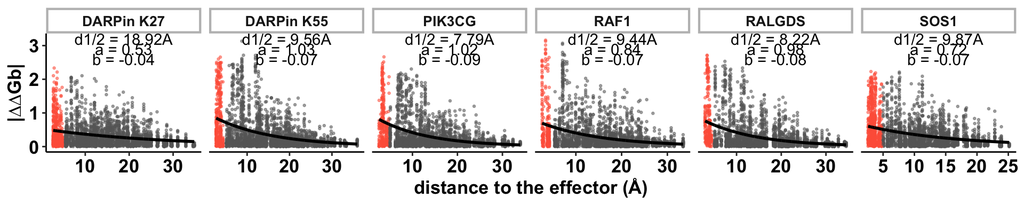

```r
# prepare half d labels
half_d_dt<-data.table(half_d_list)
half_d_dt$assay<-libraries_chenchun
half_d_dt$a<-half_a
half_d_dt$b<-half_b

midpoints <- chenchun_allo_curves_table %>%
  group_by(assay) %>%
  summarise(midpoint_x = mean(range(scHAmin_ligand)))

curve_coefficients <- half_d_dt %>%
  left_join(midpoints, by = "assay")

curve_coefficients[,half_d_list:=unlist(half_d_list)]
curve_coefficients[,label_half_d:=paste0("d1/2 = ", round(half_d_list, 2), "Å")]
curve_coefficients[, label_a:=paste0("a = ", round(as.numeric(a), 2))]
curve_coefficients[, label_b:=paste0("b = ", round(as.numeric(b), 2))]

ggplot(chenchun_allo_curves_table, aes(x=scHAmin_ligand, y=abs(ddg)))+
  geom_point(alpha=0.5, size=0.5, aes(color=binding_interface_5A))+
  scale_color_manual(values=c("grey40", "tomato"))+
  theme_classic()+
  new_scale_color()+
  geom_line(aes(x=scHAmin_ligand, y=abs(allo_predicted)), color="black", size=1)+
  facet_wrap(~assay, scale="free_x", nrow=1)+
  theme()+
  new_scale_color()+
  theme(legend.position="none",
        strip.text.x = element_text(size = 10, face = "bold"),
        strip.background = element_rect(color="grey", fill="white", size=1.5, linetype="solid"
     ))+
  geom_text(data=curve_coefficients, aes(label=label_half_d, x=midpoint_x, y=3.2), color="black", font = "bold")+
  geom_text(data=curve_coefficients, aes(label=label_a, x=midpoint_x, y=2.9), color="black", font = "bold")+
  geom_text(data=curve_coefficients, aes(label=label_b, x=midpoint_x, y=2.6), color="black", font = "bold")+
  ylab("|∆∆Gb|")+
  xlab("distance to the effector (Å)")+
  theme(axis.text.x=element_text(size=13,face="bold", color="black"),
        axis.text.y=element_text(size=13,face="bold", color="black"),
        axis.title.y=element_text(size=13,face="bold", color="black"),
        axis.title.x=element_text(size=13,face="bold", color="black"))
```

```r
ggsave(paste0("Figs/Fig4/FigS4Bdecay_curves_chenchun.png"), width=10, height=2.5)
```

```r
toni_src_ddg_dt<-as.data.table(fread(paste0("data/external_data/toni-SRC-ddgTables.txt")))
toni_src_annotation<-as.data.table(fread(paste0("data/external_data/20220620_c-SRC_annotations.txt")))

# Select key ddG columns
toni_src_ddg_dt_subset<-toni_src_ddg_dt[, c("id", "FL_activity_mean_kcal/mol", "KD_activity_mean_kcal/mol")]

# Extract numeric position from mutation ID and compute kinase numbering
toni_src_ddg_dt_subset[, Pos_ref:=extract_numeric(id)]
```

```
## extract_numeric() is deprecated: please use readr::parse_number() instead
```

```r
toni_src_ddg_dt_subset[, kinase_resno:=Pos_ref+267] # offset from construct to kinase
toni_src_ddg_dt_subset[, pos_in_uniprot:=kinase_resno]


# Add ATP-binding site annotations
ATP_active_site_pos<-unique(toni_src_annotation[smallMolecule_ion_substrate_binding=="ATP"]$position)
toni_src_ddg_dt_subset[, ATP_binding:=kinase_resno %in% ATP_active_site_pos]

# add Toni's distance-to-functional-site annotations
distance_to_catD<-fread(paste0("data/external_data/2SRC.form.CAT.tab.pdb_pairwise_distances.txt"))
distance_to_atp<-fread(paste0("data/external_data/2SRC.form.ligand.tab.pdb_pairwise_distances.txt"))
distance_to_substrate<-fread(paste0("data/external_data/2SRC.form.SUBSTRATEp.tab.pdb_pairwise_distances.txt"))


# ── Compute minimal distance per residue ──
#calculate minimum distance of all atoms in each residue and map to uniprot aa positions
mindistances_by_residue_to_catD<-data.table(aggregate(distance~kinase_resno,FUN=min,data=distance_to_catD[mol_elety %in% c("OD1","OD2"),]))
colnames(mindistances_by_residue_to_catD)[2]<-"distance_catD"
mindistances_by_residue_to_catD[,pos_in_uniprot:=kinase_resno+3]
mindistances_by_residue_to_atp<-data.table(aggregate(distance~kinase_resno,FUN=min,data=distance_to_atp))
colnames(mindistances_by_residue_to_atp)[2]<-"distance_ATP"
mindistances_by_residue_to_atp[,pos_in_uniprot:=kinase_resno+3]
mindistances_by_residue_to_substrate<-data.table(aggregate(distance~kinase_resno,FUN=min,data=distance_to_substrate[mol_elety %in% c("CG"),]))
colnames(mindistances_by_residue_to_substrate)[2]<-"distance_sub"
mindistances_by_residue_to_substrate[,pos_in_uniprot:=kinase_resno+3]


# ──  Merge all distance annotations ──
toni_src_ddg_dt_subset[,pos_in_uniprot:=kinase_resno]
toni_src_ddg_dt_subset_<-left_join(toni_src_ddg_dt_subset, mindistances_by_residue_to_substrate, by="pos_in_uniprot")
toni_src_ddg_dt_subset_<-left_join(toni_src_ddg_dt_subset_, mindistances_by_residue_to_atp, by="pos_in_uniprot")
toni_src_ddg_dt_subset_<-left_join(toni_src_ddg_dt_subset_, mindistances_by_residue_to_catD, by="pos_in_uniprot")

# Compute the minimum of all distance types per position
toni_src_ddg_dt_subset_[,mindistance:=pmin(distance_sub, distance_ATP, distance_catD)]
# Rename ddG columns for clarity
colnames(toni_src_ddg_dt_subset_)[c(2,3)]<-c("FL_ddg_activity", "KD_ddg_activity")
```

```r
# all mutations KD
xvector_starting<-toni_src_ddg_dt_subset_[pos_in_uniprot<521 & !is.na(mindistance),]$mindistance
yvector_starting<-abs(toni_src_ddg_dt_subset_[pos_in_uniprot<521 & !is.na(mindistance),]$KD_ddg_activity)

# fitting the curve (without BI)
model_2<-fit_exponential_curve(xvector=toni_src_ddg_dt_subset_[pos_in_uniprot<521 & !is.na(mindistance) & ATP_binding==F,]$mindistance,
                      yvector=abs(toni_src_ddg_dt_subset_[pos_in_uniprot<521 & !is.na(mindistance) & ATP_binding==F,]$KD_ddg_activity),plotfig=F,
                      tit="FigureS4a_allsites_allmutations")
```

```
## [1] 0.1740975
```

```r
half_ddg <- coef(model_2)[1] / 2  # 50% reduction
half_d <- log(half_ddg / coef(model_2)[1]) / coef(model_2)[2]
print(half_d) #8.29
```

```
##        a
## 8.291578
```

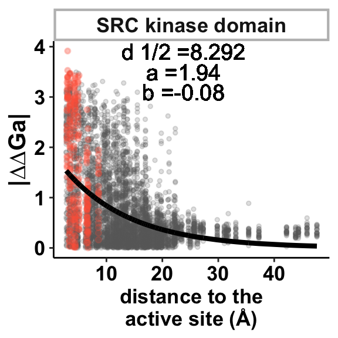

```r
# plot for toni's decay curve fitted excluding the binding interface
toni_src_ddg_dt_subset_$predicted_ddg <- coef(model_2)[1] * exp(coef(model_2)[2] * toni_src_ddg_dt_subset_$mindistance)
toni_src_ddg_dt_subset_[, library:="SRC kinase domain"]

ggplot(toni_src_ddg_dt_subset_, aes(x=mindistance, y=abs(KD_ddg_activity), color=ATP_binding))+
  geom_point(alpha=0.2, size=1)+
  geom_point(data=toni_src_ddg_dt_subset_[ATP_binding==T], alpha=0.2, color="tomato")+
  scale_color_manual(values=c("grey40", "tomato"))+
  theme_classic()+
  geom_line(aes(x=mindistance, y=predicted_ddg), color="black", size=1.5)+
  geom_text(aes(x=max(toni_src_ddg_dt_subset_$mindistance, na.rm=T)/2, y=3.9, label=paste0("d 1/2 =", round(half_d, 3))), size=5, color="black")+facet_grid(~library)+
  geom_text(aes(x=max(toni_src_ddg_dt_subset_$mindistance, na.rm=T)/2, y=3.5, label=paste0("a =", round(coef(model_2)[1], 2))), size=5, color="black")+
  geom_text(aes(x=max(toni_src_ddg_dt_subset_$mindistance, na.rm=T)/2, y=3.1, label=paste0("b =", round(coef(model_2)[2], 2))), size=5, color="black")+
  theme_classic()+
  theme(legend.position="none",
        strip.text.x = element_text(size = 13, face = "bold"),
        strip.background = element_rect(color="grey", fill="white", size=1.5, linetype="solid"
     ))+
  ylab("|∆∆Ga|")+
  xlab("distance to the\nactive site (Å)")+
  theme(axis.text.x=element_text(size=13,face="bold", color="black"),
        axis.text.y=element_text(size=13,face="bold", color="black"),
        axis.title.y=element_text(size=15,face="bold", color="black"),
        axis.title.x=element_text(size=13,face="bold", color="black"))
```

```r
ggsave(paste0("Figs/Fig4/FigS4Adecay_curves_toni.png"), width=2.8, height=3)
```

# correlation of residuals

```r
all_allo_table[,mut:=substr(id, nchar(id), nchar(id))]
all_allo_table_wide <- dcast(all_allo_table[binding_interface_contacts==F, .(structural_alignment_pos, mut, library, allo_decay_residual)], structural_alignment_pos + mut ~ library, value.var = "allo_decay_residual")

# calculate all pairwise pearson correlations
cor_matrix <- cor(all_allo_table_wide[,!c("structural_alignment_pos", "mut")], use = "pairwise.complete.obs", method="spearman")
cor_matrix[upper.tri(cor_matrix)]<--1
diag(cor_matrix)<-1
print("Overall correlation summary")
```

```
## [1] "Overall correlation summary"
```

```r
summary(as.vector((cor_matrix[cor_matrix!=-1 & cor_matrix!=1])))
```

```
##    Min. 1st Qu.  Median    Mean 3rd Qu.    Max.
##  0.4353  0.4784  0.5010  0.5256  0.5318  0.8165
```

```r
#annotate which types of comparisons are these
cor_matrix_melted<-as.data.table(reshape2:::melt.matrix(cor_matrix))
cor_matrix_melted[, value:=as.numeric(value)]
cor_matrix_melted<-cor_matrix_melted[value!=-1 & value!=1]
cor_matrix_melted[, same_pdz:=sub("^(([^_]+)_([^_]+))_.*", "\\1", Var1)==sub("^(([^_]+)_([^_]+))_.*", "\\1", Var2)]
cor_matrix_melted[, same_lig:=sub("^[^_]+_[^_]+_", "", Var1)==sub("^[^_]+_[^_]+_", "", Var2)]
cor_matrix_melted[,class2:=sub("^[^_]+_[^_]+_", "", Var1)=="cep164" | sub("^[^_]+_[^_]+_", "", Var2)=="cep164"]
cor_matrix_melted[same_pdz==T, category_comparison:="same_pdz"]
cor_matrix_melted[same_lig==T, category_comparison:="same_lig"]
cor_matrix_melted[class2==T, category_comparison:="class2"]
cor_matrix_melted[is.na(category_comparison), category_comparison:="unrelated"]

print("Correlation summary SAME pdz")
```

```
## [1] "Correlation summary SAME pdz"
```

```r
summary(cor_matrix_melted[category_comparison=="same_pdz"]$value)
```

```
##    Min. 1st Qu.  Median    Mean 3rd Qu.    Max.
##  0.8069  0.8093  0.8117  0.8117  0.8141  0.8165
```

```r
print("Correlation summary DIFFERENT pdz")
```

```
## [1] "Correlation summary DIFFERENT pdz"
```

```r
summary(cor_matrix_melted[category_comparison!="same_pdz"]$value)
```

```
##    Min. 1st Qu.  Median    Mean 3rd Qu.    Max.
##  0.4353  0.4731  0.4978  0.4955  0.5201  0.5435
```

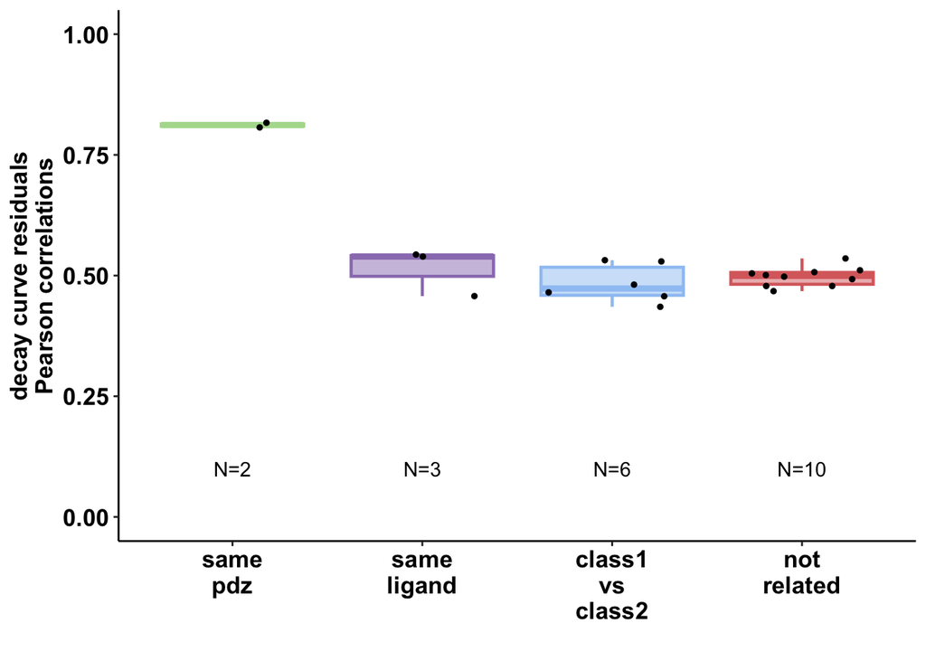

```r
n_plot<-cor_matrix_melted[, .(.N), by=category_comparison]
ggplot(cor_matrix_melted, aes(x=factor(category_comparison, levels=c("same_pdz", "same_lig", "class2", "unrelated"),labels=c("same\npdz", "same\nligand","class1\nvs\nclass2", "not\nrelated")), y=value, color=category_comparison, fill=category_comparison))+
  geom_boxplot(size=0.8, alpha=0.5)+
  geom_point(color="black", position="jitter", size=1)+
  scale_color_manual(values=c("#9EC6F3","#9B7EBD", "#B0DB9C" , "#DA6C6C"))+
  scale_fill_manual(values=c("#9EC6F3","#9B7EBD", "#B0DB9C" , "#DA6C6C"))+
  ylim(c(0,1))+
  theme_classic()+ylab("decay curve residuals\nPearson correlations")+
  xlab("")+
  theme(legend.position="none")+#+ylim(c(0,3))+
theme(axis.text.x=element_text(size=13,face="bold", color="black"),
        axis.text.y=element_text(size=13,face="bold", color="black"),
        axis.title.y=element_text(size=13,face="bold", color="black"),
        axis.title.x=element_text(size=13,face="bold", color="black"))+
  geom_text(data=n_plot, aes(y=0.1, label=paste0("N=", N)), color="black")
```

```r
ggsave(paste0("Figs/Fig4/FigS4Dresidual_correlations.png"), width=3.4, height=3.4)
```

```r
######## calculate the test ########
allo_significant_mutations<-all_allo_table[binding_interface_contacts==F, .(Z_Score = (allo_decay_residual) / std_ddg, std_ddg=std_ddg, allo_decay_residual=allo_decay_residual), by=.(library, structural_alignment_pos, mut)]
allo_significant_mutations[, P_Value := pnorm(-Z_Score)]  # one-sided test: Z > 0, pnorm(-Z_Score) means you are getting the upper-tail probability for positive Z-scores. This is a one-sided test looking at whether the Z_Score is significantly greater than 0.
allo_significant_mutations$adjusted_p<-p.adjust(allo_significant_mutations$P_Value, method="fdr")


######## select the ones that are significant ########
allo_significant_mutations[, significant_residual:=adjusted_p<0.1 & allo_decay_residual>0]


######## calculate the percentages of signficant mutations ########
allo_significant_percentages<-allo_significant_mutations[, .(total_significant_residual=sum(significant_residual), total=.N), by=(library)]
allo_significant_percentages[,percentage:=total_significant_residual/total]
print(allo_significant_percentages$percentage)
```

```
## [1] 0.04354588 0.14198370 0.16460905 0.15257958 0.14478114 0.12747875 0.14635905
```

```r
summary(allo_significant_percentages$percentage*100)
```

```
##    Min. 1st Qu.  Median    Mean 3rd Qu.    Max.
##   4.355  13.473  14.478  13.162  14.947  16.461
```

Across pairwise comparisons, only a median of 7.3% of these unusually strong allosteric mutations identified in one interaction are also classified as unexpectedly allosteric in a second PDZ domain. However, the overlap for the same PDZ domain binding different ligands is larger, increasing to a median of 41.4%

```r
# Ooverall correlations but also the correlations of the allosteric sites
# first correlations of allo decay residuals
allo_significant_mutations[,.(library,structural_alignment_pos, mut, allo_decay_residual)]
```

```
##                 library structural_alignment_pos    mut allo_decay_residual
##                  <char>                    <int> <char>               <num>
##     1: psd95_pdz3_cript                       11      A         -0.12903980
##     2: psd95_pdz3_cript                       11      C          0.13330176
##     3: psd95_pdz3_cript                       11      D         -0.11069471
##     4: psd95_pdz3_cript                       11      E         -0.17750554
##     5: psd95_pdz3_cript                       11      F          0.04149039
##    ---
## 10968: erbin_pdz1_cript                      104      R         -0.04649621
## 10969: erbin_pdz1_cript                      104      S         -0.11245928
## 10970: erbin_pdz1_cript                      104      T         -0.10283437
## 10971: erbin_pdz1_cript                      104      W         -0.04259992
## 10972: erbin_pdz1_cript                      104      Y         -0.07657848
```

```r
allo_significant_wide <- dcast(allo_significant_mutations[significant_residual==T], structural_alignment_pos + mut ~ library, value.var = "allo_decay_residual")
# then correlations of ddG

# Get only library columns
lib_cols <- setdiff(names(allo_significant_wide), c("structural_alignment_pos", "mut"))

# Initialize matrix to store overlap percentages
overlap_matrix <- matrix(NA, nrow = length(lib_cols), ncol = length(lib_cols),
                         dimnames = list(lib_cols, lib_cols))

# Calculate pairwise overlaps
for (i in seq_along(lib_cols)) {
  for (j in seq_along(lib_cols)) {
    col1 <- lib_cols[i]
    col2 <- lib_cols[j]

      not_na1 <- !is.na(allo_significant_wide[[col1]])
    not_na2 <- !is.na(allo_significant_wide[[col2]])

    both_not_na <- sum(not_na1 & not_na2)
    either_not_na <- sum(not_na1 | not_na2)

    overlap_matrix[i, j] <- round(both_not_na / either_not_na, 3)  # percentage shared
  }
}

overlap_matrix[upper.tri(overlap_matrix)]<--1
summary(as.vector((overlap_matrix[overlap_matrix!=-1])))
```

```
##    Min. 1st Qu.  Median    Mean 3rd Qu.    Max.
##  0.0400  0.0685  0.1220  0.3412  0.6415  1.0000
```

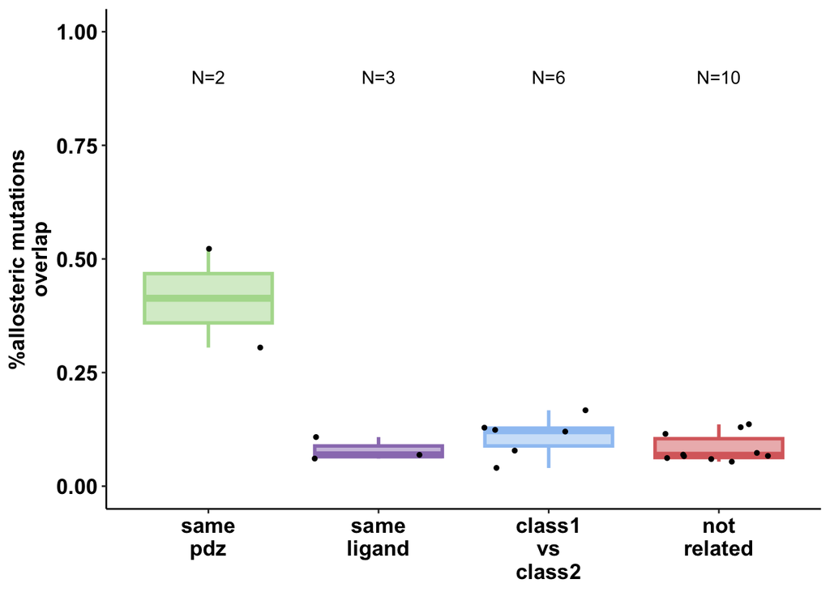

```r
overlap_matrix_melted<-as.data.table(reshape2::melt(overlap_matrix))
overlap_matrix_melted<-overlap_matrix_melted[value!=-1 & value!=1]
overlap_matrix_melted[, same_pdz:=sub("^(([^_]+)_([^_]+))_.*", "\\1", Var1)==sub("^(([^_]+)_([^_]+))_.*", "\\1", Var2)]
overlap_matrix_melted[, same_lig:=sub("^[^_]+_[^_]+_", "", Var1)==sub("^[^_]+_[^_]+_", "", Var2)]
overlap_matrix_melted[,class2:=sub("^[^_]+_[^_]+_", "", Var1)=="cep164" | sub("^[^_]+_[^_]+_", "", Var2)=="cep164"]
overlap_matrix_melted[same_pdz==T, category_comparison:="same_pdz"]
overlap_matrix_melted[same_lig==T, category_comparison:="same_lig"]
overlap_matrix_melted[class2==T, category_comparison:="class2"]
overlap_matrix_melted[is.na(category_comparison), category_comparison:="unrelated"]

n_plot<-overlap_matrix_melted[, .(.N), by=category_comparison]
ggplot(overlap_matrix_melted[Var1!=Var2], aes(x=factor(category_comparison, levels=c("same_pdz", "same_lig", "class2", "unrelated"),labels=c("same\npdz", "same\nligand","class1\nvs\nclass2", "not\nrelated")), y=value, color=category_comparison, fill=category_comparison))+
  geom_boxplot(alpha=0.5, size=1)+
  geom_point(color="black", position="jitter", size=1)+
  scale_color_manual(values=c("#9EC6F3","#9B7EBD", "#B0DB9C" , "#DA6C6C"))+
  scale_fill_manual(values=c("#9EC6F3","#9B7EBD", "#B0DB9C" , "#DA6C6C"))+
  ylab("%allosteric mutations\noverlap")+
  theme_classic()+
  theme(legend.position="none", axis.title.x=element_blank())+ylim(c(0,1))+#+ylim(c(0,3))+
theme(axis.text.x=element_text(size=13,face="bold", color="black"),
        axis.text.y=element_text(size=13,face="bold", color="black"),
        axis.title.y=element_text(size=13,face="bold", color="black"))+
  geom_text(data=n_plot, aes(y=0.9, label=paste0("N=", N)), color="black")
```

```r
ggsave(paste0("Figs/Fig4/FigS4Eoverlap_allo_mut_percentages.png"), width=3.4, height=3.4)

summary(overlap_matrix_melted[same_pdz==T]$value)
```

```
##    Min. 1st Qu.  Median    Mean 3rd Qu.    Max.
##  0.3050  0.3593  0.4135  0.4135  0.4677  0.5220
```

```r
summary(overlap_matrix_melted[same_pdz!=T]$value)
```

```
##    Min. 1st Qu.  Median    Mean 3rd Qu.    Max.
## 0.04000 0.06400 0.07300 0.09095 0.12200 0.16700
```

# Define allosteric hotspots

We define allosteric hotspots as positions where mutations cause larger changes in ∆∆Gb than expected at their distance from the ligand (FDR<0.05, one-sided t-test; median |∆∆Gb| > 0.2kcal/mol) (see methods, Fig. 4d,f and Extended Data fig. 4f).

```r
all_allo_table_define_hotspots<-all_allo_table

# positions where median |ddG| is higher than a threshold
ddG_threshold<-0.2
allo_hotspots_candidates<-all_allo_table_define_hotspots[,.(median_ddg=median(abs(ddg))), by=.(library, structural_alignment_pos)][, candidate_ddg:=median_ddg>ddG_threshold]

# Get which position's residual distributions are statistically >> 0
residual_distributions_test_results <- all_allo_table_define_hotspots[
  !is.na(allo_decay_residual),  # Ensure allo_decay_residual is not NA
  .(
    p_value = if (.N > 1 && length(unique(allo_decay_residual)) > 1) {
      t.test(allo_decay_residual, mu = 0, alternative = "greater")$p.value
    } else {
      NA_real_  # Use numeric NA for consistency
    }
  ),
  by = .(library, structural_alignment_pos)
]
residual_distributions_test_results[, p_adjusted := p.adjust(p_value, method = "fdr")]
residual_distributions_test_results[,significant_residual_distribution:=p_adjusted<0.05]

### join both filters and define hotspots
test_results_complete<-left_join(residual_distributions_test_results, allo_hotspots_candidates)
significant_distributions<-test_results_complete[candidate_ddg==T & significant_residual_distribution==T]

test_results_complete[, allo_hotspot:= candidate_ddg==T & significant_residual_distribution==T]
test_results_complete<-left_join(all_allo_table[binding_interface_contacts==F], test_results_complete)
# define which are the conserved hotspots
conserved_hotspots<-test_results_complete[allo_hotspot==T, .N, by = .(structural_alignment_pos, pdz)][, .N, by = .(structural_alignment_pos)][N>=3]

allo_hotspots_dt<-test_results_complete
```

## store the results in the supplemmentary table

```r
Supplementary_table6<-fread(paste0("supplementary_tables/Supplementary_table6_BI.txt"))

colnames(Supplementary_table6)[1]<-"library_name"

allo_hotspots_dt_<-allo_hotspots_dt[, .(median_ddg=median(ddg), median_abs_ddg=median(abs(ddg)), mean_ddg=mean(ddg), rsasa=rsasa[1], p_value=p_value[1], p_adjusted=p_adjusted[1], allo_hotspot=allo_hotspot[1]), by=.(library_name, structural_alignment_pos, Uniprot_pos_ref.x)]

allo_hotspots_dt_$ALLO_hotspot_class<-"non-Hotspot"

allo_hotspots_dt_[structural_alignment_pos %in% conserved_hotspots$structural_alignment_pos & allo_hotspot==T, ALLO_hotspot_class:="Hotspot in >2/5 PDZs"]

allo_hotspots_dt_[!structural_alignment_pos %in% conserved_hotspots$structural_alignment_pos & allo_hotspot==T, ALLO_hotspot_class:="Hotspot"]

allo_hotspots_dt_[,class:="allostery (outside BI)"]
colnames(allo_hotspots_dt_)[3]<-"Uniprot_pos_ref"

complete_hotspots_table<-merge(allo_hotspots_dt_, Supplementary_table6, by=c("library_name", "structural_alignment_pos", "Uniprot_pos_ref", "median_ddg", "mean_ddg", "rsasa", "p_value", "p_adjusted", "class"), all = T)

fwrite(complete_hotspots_table, paste0("supplementary_tables/Supplementary_table6.txt"))
```

## boxplot distributions of residuals

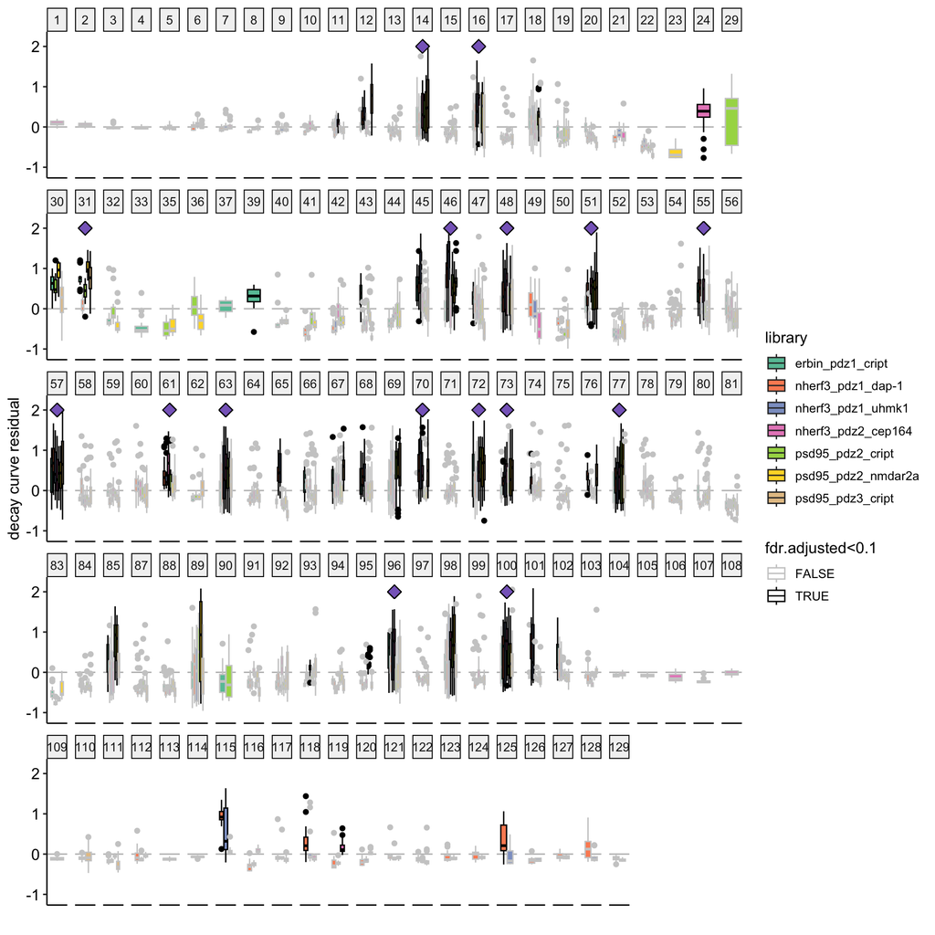

```r
ggplot(test_results_complete)+
  geom_hline(aes(yintercept = 0), color="grey")+
  geom_boxplot(aes(x=factor(structural_alignment_pos), y=allo_decay_residual, fill=library, color=allo_hotspot))+
  theme_pubr()+
  scale_fill_brewer(palette="Set2")+
  scale_color_manual("fdr.adjusted<0.1", values=c("grey80", "black"))+
  facet_wrap(~structural_alignment_pos, scales="free_x", nrow=5)+
  geom_point(data=test_results_complete[structural_alignment_pos %in% conserved_hotspots$structural_alignment_pos,], aes(x=1, y=2), shape=23, size=3.5, fill="#886ac4")+xlab("")+ylab("decay curve residual")+ylim(c(-1.1,2.2))+
  theme(legend.position="right", axis.text.x = element_blank(), axis.ticks.x = element_blank())
```

```r
structure_colors <- c(
  "helix" = "#ffcccc",   # light red
  "sheet" = "#ccccff",  # light green
  "loop" = "white"     # light blue
)

# annotate the conserved hotspots vs non conserved
test_results_complete[structural_alignment_pos %in% conserved_hotspots$structural_alignment_pos & allo_hotspot==T, hotspot_class:="hotspot in >2 PDZs"]
test_results_complete[!structural_alignment_pos %in% conserved_hotspots$structural_alignment_pos & allo_hotspot==T, hotspot_class:="hotspot in 1 or 2 PDZs"]
test_results_complete[allo_hotspot==F, hotspot_class:="not Hotspot"]


test_results_complete$library<-lib_code_to_name(test_results_complete$library, libraries, libraries_names)
test_results_complete<-left_join(test_results_complete, all_ddg_table[,.(library,structural_alignment_pos,ddg)][, ddg_not_abs:=ddg][,-c("ddg")])
test_results_complete_median<-left_join(test_results_complete[,-c("median_ddg")], all_median_ddg_table[!is.na(scHAmin_ligand),.(library,structural_alignment_pos,median_ddg)])
```

```r
test_results_complete_median[median_ddg<0, allo_predicted:=-allo_predicted]

# library names for the plots
test_results_complete_median$library_name<-gsub("_", "-", gsub(" binding ", " | ", (unlist(lapply(test_results_complete_median$library, lib_code_to_name, libraries_names, libraries_names_plots)))))

pdb_metrics_dt$library_name<-gsub("_", "-", gsub(" binding ", " | ", (unlist(lapply(pdb_metrics_dt$library, lib_code_to_name, libraries_names, libraries_names_plots)))))

BI_hotspots_dt$library_name<-gsub("\n", " | ", BI_hotspots_dt$lib_name)


p<-ggplot(test_results_complete_median[binding_interface_contacts==F], aes(x=factor(structural_alignment_pos), y=ddg))+
  geom_tile(data=pdb_metrics_dt[!is.na(scHAmin_ligand)], aes(y = 2, fill = secondary_structure),
            height = Inf) +
  geom_boxplot(aes(color=hotspot_class, group=structural_alignment_pos), outliers=F)+
  scale_fill_manual(values = structure_colors) +#, guide = "none") +
  geom_boxplot(data=BI_hotspots_dt, aes(x=structural_alignment_pos, y=ddg, color=hotspot_class, group=structural_alignment_pos), outliers=F, color="tomato")+
  scale_fill_manual(values = structure_colors) +
  geom_point(aes(x=factor(structural_alignment_pos), y=allo_predicted), color="blue", size=0.5)+
  scale_color_manual(values=c("black", "green3", "grey"))+
  theme_classic()+
  facet_wrap(~library_name, ncol=1)+
  geom_hline(aes(yintercept = 0), color="grey50")+
  scale_x_discrete(breaks=seq(5,129,by=5))+
  theme(legend.position="none",
        strip.text.x = element_text(size = 10, face = "bold"),
        strip.background = element_rect(color="grey", fill="white", size=1.5, linetype="solid"
     ))+ylab("|∆∆Gb|")+xlab("Structural alignment position")+
  theme(axis.text.x=element_text(size=13, color="black"),
        axis.text.y=element_text(size=13, color="black"),
        axis.title.y=element_text(size=13,color="black"),
        axis.title.x=element_text(size=13, color="black"))
ggsave(paste0("Figs/Fig4/FigS4Fboxplots_all.png"), width=13, height=9)
```

A small figure to help explain how we classified the hotspots

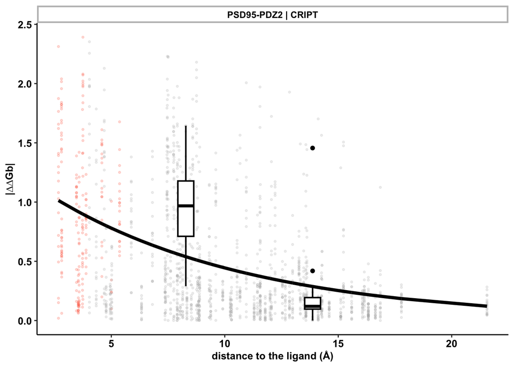

```r
ggplot(all_allo_table[library=="psd95_pdz2_cript"], aes(x=scHAmin_ligand, y=ddg))+
  geom_point(alpha=0.2, size=0.7, aes(color=binding_interface_contacts))+
  scale_color_manual(values=c("grey70", "tomato"))+
  new_scale_color()+
  geom_line(aes(x=scHAmin_ligand, y=allo_predicted), color="black", size=1.5)+
  scale_color_brewer(palette="Set2")+
  geom_boxplot(data=all_allo_table[library=="psd95_pdz2_cript" & structural_alignment_pos %in% c(57, 64)], size=0.7, aes(group=structural_alignment_pos), width=0.7, color="black")+
  facet_grid(~library_name, scale="free_x")+
  facet_grid2(~library_name, strip = strip_themed(
    text_x = elem_list_text(face = "bold", colour = "black")), scale="free_x") +
  theme_classic()+
  theme(legend.position="none",
        strip.text.x = element_text(size = 9, face = "bold"),
        strip.background = element_rect(color="grey", fill="white", size=1.5, linetype="solid"
     ))+
  ylab("|∆∆Gb|")+
  xlab("distance to the ligand (Å)")+
  theme(axis.text.x=element_text(size=10,face="bold", color="black"),
        axis.text.y=element_text(size=10,face="bold", color="black"),
        axis.title.y=element_text(size=10,face="bold", color="black"),
        axis.title.x=element_text(size=10,face="bold", color="black"))
```

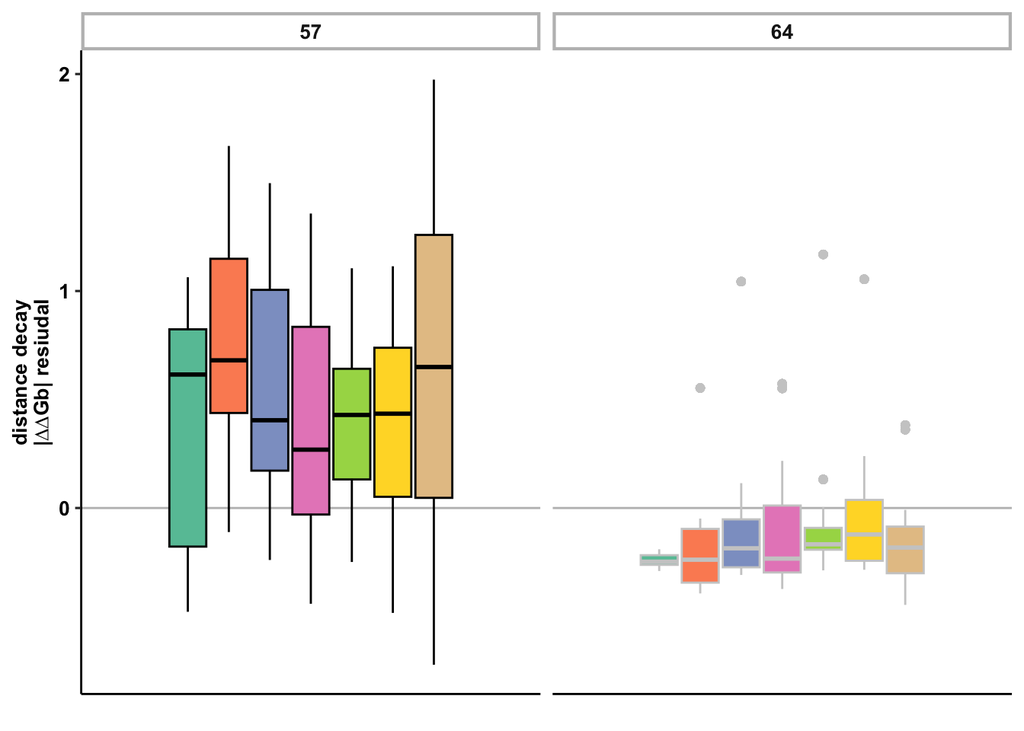

```r
ggsave(paste0("Figs/Fig4/Fig4Ddecay_dstributions_examples.pdf"), width=2.1, height=2)
ggplot(test_results_complete[structural_alignment_pos %in% c(57, 64)])+
  geom_hline(aes(yintercept = 0), color="grey")+
  geom_boxplot(aes(x=factor(structural_alignment_pos), y=allo_decay_residual, fill=library, color=allo_hotspot))+
  theme_pubr()+
  scale_fill_brewer(palette="Set2")+
  scale_color_manual("fdr.adjusted<0.1", values=c("grey80", "black"))+
  facet_wrap(~structural_alignment_pos, scales="free_x", nrow=1)+
  theme(legend.position="none")+
  xlab("")+
  ylab("distance decay\n|∆∆Gb| resiudal")+
  theme(legend.position="none",
        axis.text.x=element_blank(),
        axis.ticks.x = element_blank(),
        axis.title.x = element_blank(),
        strip.text.x = element_text(size = 10, face = "bold"),
        strip.background = element_rect(color="grey", fill="white", size=1.5, linetype="solid"
     ))+
  theme(axis.text.y=element_text(size=10,face="bold", color="black"),
        axis.title.y=element_text(size=10,face="bold", color="black"),
        axis.title.x=element_text(size=10,face="bold", color="black"))
```

```r
ggsave(paste0("Figs/Fig4/Fig4Ddecay_dstributions_examples2.pdf"), width=2.1, height=2.2)
```

# effects of hotspots are comparable to those in the binding intreface

For each interaction, this defines a median of 19.6% of the positions outside the binding interface as allosteric hotspots (range 17.4% to 24.7%). Mutations in these allosteric hotspots cause changes in binding energy comparable in magnitude to mutations in the binding interface (Fig. 4g and Extended Data Fig. 4g).

```r
# define which are the conserved allosteric hotspots
allo_hotspots_dt[, allo_consv_hotspot:=structural_alignment_pos %in% conserved_hotspots$structural_alignment_pos & allo_hotspot==T]

# complete the ddG data with this hotspots definition
allo_hotspots_dt$library<-lib_code_to_name(allo_hotspots_dt$library, libraries, libraries_names)
all_ddg_table_allo<-left_join(all_ddg_table[assay=="binding"], allo_hotspots_dt[,c("library","structural_alignment_pos", "allo_hotspot", "allo_consv_hotspot")])
```

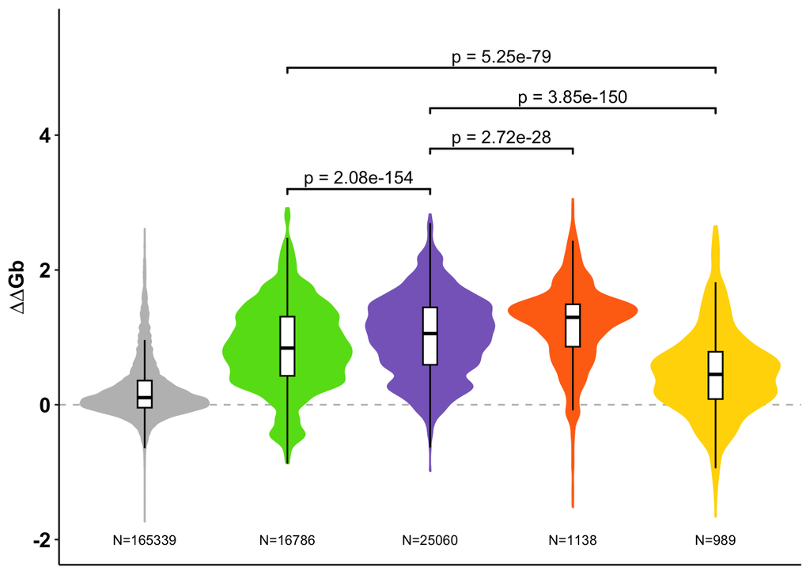

```r
all_ddg_table_allo[is.na(allo_consv_hotspot), allo_consv_hotspot:=F]
all_ddg_table_allo[is.na(allo_hotspot), allo_hotspot:=F]
all_ddg_table_allo[, class:=as.integer(allo_hotspot)]
all_ddg_table_allo[allo_consv_hotspot==T, class:=2]
levels(all_ddg_table_allo$class)<-as.character(c(0,1,2,3,4))
all_ddg_table_allo[, BI_hotspot:=structural_alignment_pos %in% BI_hotspots]
all_ddg_table_allo[BI_hotspot==T, class:=3]
all_ddg_table_allo[BI_hotspot==F & binding_interface_contacts==T,]$class<-"4"
all_ddg_table_allo$class<-as.factor(all_ddg_table_allo$class)

labels_plot<-c("Not Hotspot", "Allosteric\nHotspot\nin 1 or 2 PDZs", "Allosteric\nHotspot\nin >2/5 PDZs","BI\nconserved\nhotspots", "BI\nnon-hotspot")

all_ddg_table_allo[, class_plot :=
  factor(class,
         levels = 0:4,
         labels = labels_plot)]

p_dt <- rbindlist(list(
  data.table(group1 = labels_plot[2],
             group2 = labels_plot[3],
             p = wilcox.test(ddg ~ class_plot,
                             data = all_ddg_table_allo[class %in% c(1,2)])$p.value),

  data.table(group1 = labels_plot[3],
             group2 = labels_plot[4],
             p = wilcox.test(ddg ~ class_plot,
                             data = all_ddg_table_allo[class %in% c(2,3)])$p.value),

  data.table(group1 = labels_plot[3],
             group2 = labels_plot[5],
             p = wilcox.test(ddg ~ class_plot,
                             data = all_ddg_table_allo[class %in% c(2,4)])$p.value),

  data.table(group1 = labels_plot[2],
             group2 = labels_plot[5],
             p = wilcox.test(ddg ~ class_plot,
                             data = all_ddg_table_allo[class %in% c(1,4)])$p.value)
))
p_dt[, label := sprintf("p = %.2e", p)]
p_dt[, y.position := c(3.2, 3.8, 4.4, 5.0)]




n_plot<-all_ddg_table_allo[, .(.N) , by=class_plot]
ggplot(all_ddg_table_allo,aes(x=class_plot, y=ddg, fill=class_plot, color=class_plot))+
  geom_hline(aes(yintercept=0), color="grey", linetype="dashed")+
  geom_violin(scale="width")+
  geom_boxplot(width=0.1, fill="white", color="black", outliers=F)+
  scale_fill_manual("",values=c( "grey", "#64dd17", "#886ac4", "#FF7013", "gold"))+
  scale_color_manual("",values=c("grey", "#64dd17", "#886ac4", "#FF7013", "gold"))+
  theme_classic()+
  ylim(c(-2,5.5))+
  xlab("Conserved hotspot")+
  ylab("∆∆Gb")+
  theme(legend.position = "none",
        axis.title.x=element_blank(),
        axis.text.x=element_blank(),
        axis.ticks.x=element_blank()
        )+
  theme(axis.text.y=element_text(size=13,face="bold", color="black"),
        axis.title.y=element_text(size=13,face="bold", color="black"))+
  geom_text(data=n_plot, aes(y=-2, label=paste0("N=", N)), size=3, color="black")+
  stat_pvalue_manual(p_dt,label = "label",y.position = "y.position",xmin = "group1",xmax = "group2",bracket.size = 0.6,tip.length = 0.01,inherit.aes = FALSE)
```

```r
ggsave(paste0("Figs/Fig4/Fig4Ghotspots_distributions.pdf"), width=4.3, height=3)
```

same figure but separated per library

```r
labels_plot<-c("Other\nresidues", "Allostery\nvariable\nhotspots", "Allostery\nconserved\nhotspots"," BI\nconserved\nhotspots", "Other\nBI\ncontacts")

all_ddg_table_allo$library_name<-gsub("_", "-", gsub(" binding ", " | ", (unlist(lapply(all_ddg_table_allo$library, lib_code_to_name, libraries_names, libraries_names_plots)))))

comparisons <- list(
  c(1, 2),
  c(2, 3),
  c(2, 4),
  c(1, 4)
)

pvals <- as.data.frame(all_ddg_table_allo) %>%
  group_by(library_name) %>%
  group_modify(~{

    dat <- .x

    valid_comparisons <- comparisons[
      sapply(comparisons, function(comp) {
        sum(dat$class == comp[1]) > 1 &&
        sum(dat$class == comp[2]) > 1
      })
    ]

    if(length(valid_comparisons) == 0) return(tibble())

    dat %>%
      wilcox_test(ddg ~ class,
                  comparisons = valid_comparisons) %>%
      adjust_pvalue(method = "BH")
  }) %>%
  ungroup()


pvals
```

```
## # A tibble: 28 × 10
##    library_name      .y.   group1 group2    n1    n2 statistic        p    p.adj
##    <chr>             <chr> <chr>  <chr>  <int> <int>     <dbl>    <dbl>    <dbl>
##  1 ERBIN-PDZ1 | CRI… ddg   1      2       3610  1805   2461659 8.04e-49 3.22e-48
##  2 ERBIN-PDZ1 | CRI… ddg   2      3       1805   114    100092 6.26e- 1 6.26e- 1
##  3 ERBIN-PDZ1 | CRI… ddg   2      4       1805   209    288591 3.47e-36 6.94e-36
##  4 ERBIN-PDZ1 | CRI… ddg   1      4       3610   209    534451 3.53e-24 4.71e-24
##  5 NHERF3-PDZ1 | DA… ddg   1      2       3610  3610   5002016 1.56e-65 6.24e-65
##  6 NHERF3-PDZ1 | DA… ddg   2      3       3610   114    132886 1.13e-10 1.13e-10
##  7 NHERF3-PDZ1 | DA… ddg   2      4       3610   113    350075 1.47e-38 2.94e-38
##  8 NHERF3-PDZ1 | DA… ddg   1      4       3610   113    330771 1.84e-29 2.45e-29
##  9 NHERF3-PDZ1 | UH… ddg   1      2       2527  3971   4183268 1.11e-29 4.44e-29
## 10 NHERF3-PDZ1 | UH… ddg   2      3       3971   114    149093 4.89e-10 4.89e-10
## # ℹ 18 more rows
## # ℹ 1 more variable: p.adj.signif <chr>
```

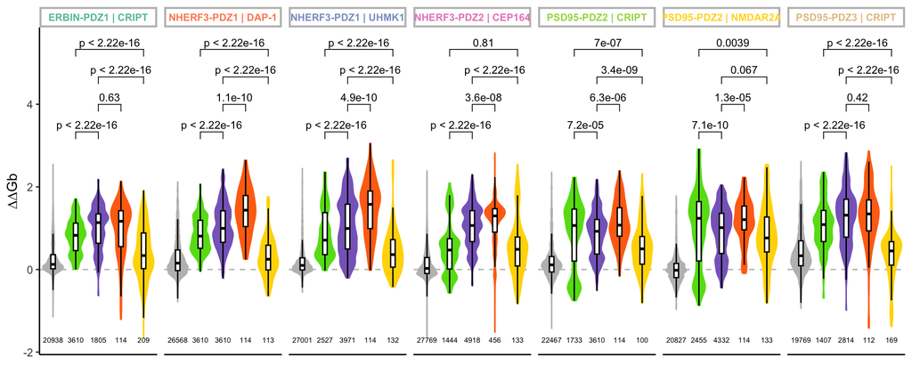

```r
n_plot<-all_ddg_table_allo[, .(.N) , by=.(class, library_name)]
ggplot(all_ddg_table_allo,aes(x=factor(class, levels=c(0,1,2,3,4), labels=labels_plot), y=ddg, fill=factor(class, levels=c(0,1,2,3,4), labels=labels_plot), color=factor(class, levels=c(0,1,2,3,4))))+
  geom_hline(aes(yintercept=0), color="grey", linetype="dashed")+
  geom_violin(scale="width")+
  geom_boxplot(width=0.2, fill="white", color="black", outliers=F)+
  scale_fill_manual("",values=c( "grey", "#64dd17", "#886ac4", "#FF7013", "gold"))+
  scale_color_manual("",values=c("grey", "#64dd17", "#886ac4", "#FF7013", "gold"))+
  stat_compare_means(comparisons=list(c("Allostery\nvariable\nhotspots", "Allostery\nconserved\nhotspots"),c("Allostery\nconserved\nhotspots"," BI\nconserved\nhotspots"), c("Allostery\nconserved\nhotspots", "Other\nBI\ncontacts"), c("Allostery\nvariable\nhotspots", "Other\nBI\ncontacts")),aes(label=after_stat(p)), size=3)+
  theme_classic()+
  ylim(c(-1.7,5.5))+
  xlab("Conserved hotspot")+
  ylab("∆∆Gb")+
  theme(legend.position = "none",
        axis.title.x=element_blank(),
        axis.text.x=element_blank(),
        axis.ticks.x=element_blank(),
        )+
  facet_grid2(~library_name, strip = strip_themed(
    text_x = elem_list_text(face = "bold", colour = facet_colors)), scale="free_x") +
  theme(legend.position="none",
        strip.text.x = element_text(size = 8, face = "bold"),
        strip.background = element_rect(color="grey", fill="white", size=1.5, linetype="solid"
     ))+
  geom_text(data=n_plot, aes(y=-1.7, label=paste0( N)), size=2, color="black")
```

```r
ggsave(paste0("Figs/Fig4/FigS4Ghotspots_distributions_per_lib.pdf"), width=12, height=3)
```

## how many hotspots per interaction

For each interaction, this defines a median of 19.6% of the positions outside the binding interface as allosteric hotspots (range 17.4% to 24.7%).

```r
percentage_allo_sites<-allo_hotspots_dt[,.(allo_hotspot=allo_hotspot[1]) ,by=.(structural_alignment_pos, library)][, .(allo_sites=sum(allo_hotspot), total=.N), by=.(library)]

percentage_allo_sites[,percentage:=allo_sites/total]
summary(percentage_allo_sites$percentage*100)
```

```
##    Min. 1st Qu.  Median    Mean 3rd Qu.    Max.
##   17.39   19.29   19.59   20.29   20.91   24.68
```

Across the five proteins, 43 different positions are allosteric hotspots for at least one interaction while 78 positions are not hotspots for any interaction (Fig. 4e).

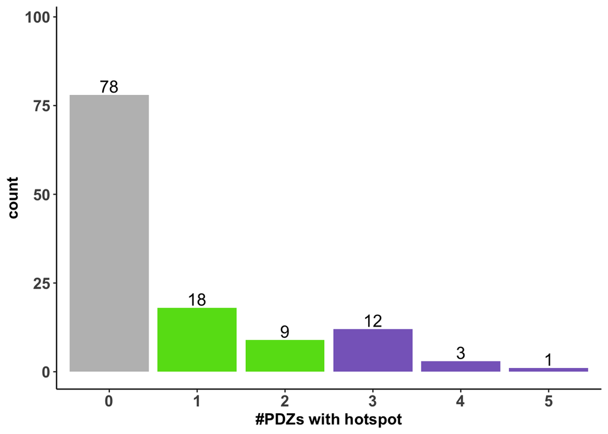

```r
allo_color_palette<-c( "grey", "#64dd17", "#886ac4", "#FF7013", "gold")
hotspots_count<-allo_hotspots_dt[allo_hotspot==T, .N, by = .(structural_alignment_pos, pdz)][, .N, by = .(structural_alignment_pos)]

pdb_metrics_dt[is.na(binding_interface_contacts), binding_interface_contacts:=F]
no_hotspot_counts_dt<-data.table(structural_alignment_pos=unique(pdb_metrics_dt[!is.na(scHAmin_ligand) & !structural_alignment_pos %in% hotspots_count$structural_alignment_pos & binding_interface_contacts==F]$structural_alignment_pos))

no_hotspot_counts_dt[,N:=0]
hotspots_count<-rbind(hotspots_count, no_hotspot_counts_dt)

ggplot(hotspots_count, aes(x=factor(N), fill=factor(N)))+
  geom_bar()+
  scale_fill_manual(values=c("grey", "#64dd17", "#64dd17", "#886ac4", "#886ac4", "#886ac4"))+
  scale_x_discrete(breaks=c(0,1,2,3,4,5))+
  theme_classic()+
  theme(legend.position="none")+
  xlab("#PDZs with hotspot")+
  geom_text(
        stat = "count",
        aes(
            label = after_stat(count)
        ),
        position = position_dodge(),
        color = "black",
        size = 5,
        vjust = -0.2
    )+ylim(c(0, 86+12))+
  theme(axis.text.x=element_text(size=13,face="bold"),
        axis.text.y=element_text(size=13,face="bold"),
        axis.title.y=element_text(size=13,face="bold"),
        axis.title.x=element_text(size=13,face="bold"))
```

```r
ggsave(paste0("Figs/Fig4/Fig4Ehotspots_per_pdz_2.pdf"), width=3, height=4)
```

How many are hotspots in all interactions

```r
hotspots_count[N==5]
```

```
##    structural_alignment_pos     N
##                       <int> <num>
## 1:                       57     5
```

One position (A57 in α1 helix) is an allosteric hotspot in all seven PDZ domain interactions tested (Fig. 4e,h & Extended Data fig. 4f). Position A57 contacts the carboxylate-binding loop in all interactions and was previously reported as allosteric in PTP-BL-PDZ2 (A46) and PSD95-PDZ3 (A347).

```r
for(lib in libraries_binding_names){
  carboxylate_b_loop<-c(24,25,26)
  target<-57
  carboxylate_b_loop_pos<-pdb_metrics_dt[library==lib & structural_alignment_pos %in% carboxylate_b_loop]$Pos
  target_pos<-pdb_metrics_dt[library==lib & structural_alignment_pos==target]$Pos
  print(lib)
  print(nrow(get_contacts_dt[Pos_1 %in% target_pos & Pos_2 %in% carboxylate_b_loop_pos])>0)
}
```

```
## [1] "psd95_pdz3_cript"
## [1] TRUE
## [1] "psd95_pdz2_cript"
## [1] TRUE
## [1] "psd95_pdz2_nmdar2a"
## [1] TRUE
## [1] "nherf3_pdz2_cep164"
## [1] TRUE
## [1] "nherf3_pdz1_dap-1"
## [1] TRUE
## [1] "nherf3_pdz1_uhmk1"
## [1] TRUE
## [1] "erbin_pdz1_cript"
## [1] TRUE
```

# Alignment of PDZs coloured by hotspots

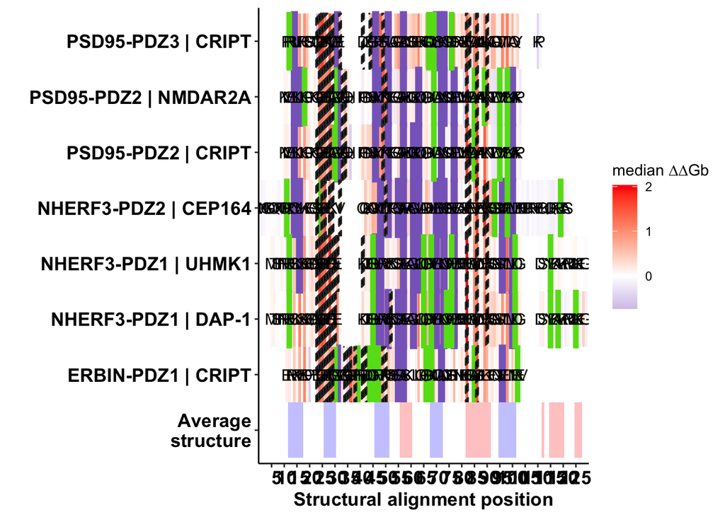

```r
plot_alignment_dt<-left_join(all_median_ddg_table[assay=="binding"], allo_hotspots_dt[,.(allo_hotspot=allo_hotspot[1]), by=.(structural_alignment_pos, library)])
plot_alignment_dt[,pdz:=as.integer(pdz)]
plot_alignment_dt[, allo_consv_hotspot:=structural_alignment_pos %in% conserved_hotspots$structural_alignment_pos]
plot_alignment_dt$library_name<-gsub("_", "-", gsub(" binding ", " | ", (unlist(lapply(plot_alignment_dt$library, lib_code_to_name, libraries_names, libraries_names_plots)))))

# Annotate the most common secondary structure per position to annotate that.
most_common_structure <- plot_alignment_dt[, .N, by = .(structural_alignment_pos, secondary_structure)][
  order(-N), .SD[1], by = structural_alignment_pos]
most_common_structure[, library_name := "Average\nstructure"]

library(ggpattern)

structure_colors <- c(
  "helix" = "#ffcccc",   # light red
  "sheet" = "#ccccff",  # light green
  "loop" = "white"     # light blue
)

ggplot(plot_alignment_dt, aes(x = factor(structural_alignment_pos), y = library_name, fill = median_ddg, label=WT_aa)) +
  geom_tile()+
  geom_tile(data=plot_alignment_dt[allo_consv_hotspot==T & allo_hotspot==T,], fill="transparent", color="#886ac4", size=1.5)+
  geom_tile(data=plot_alignment_dt[allo_hotspot==T & allo_consv_hotspot==F,], fill="transparent", color="#64dd17", size=1)+
  geom_tile_pattern(data=plot_alignment_dt[assay=="binding" & binding_interface_contacts==T],
    aes(pattern = value > 0),  # Dashed pattern based on a condition
    pattern = "stripe",        # Use stripe pattern
    pattern_density = 0.5,     # Adjust stripe density
    pattern_angle = 45,        # Adjust stripe angle
    pattern_fill = "black",    # Stripe color
    pattern_spacing = 0.03     # Adjust stripe spacing
  ) +
  scale_fill_gradient2(low = "#886ac4", mid = "white", high = "red", midpoint = 0) +
  theme_classic() +
  scale_x_discrete(limits=c(1:129), breaks=seq(5,129,5))+
  labs(x = "Structural alignment position", y = "", fill="median ∆∆Gb")+
  geom_text()+
  new_scale("fill")+
  geom_tile(data=most_common_structure, aes(x=structural_alignment_pos, y=library_name, fill=secondary_structure), inherit.aes = F, show.legend = FALSE)+
  scale_fill_manual(values=structure_colors, name = "secondary\nstructure")+
  theme(axis.text.x=element_text(size=13,face="bold", color="black"),
        axis.text.y=element_text(size=13,face="bold", color="black"),
        axis.title.y=element_text(size=13,face="bold", color="black"),
        axis.title.x=element_text(size=13,face="bold", color="black"))
```

```r
ggsave(paste0("Figs/Fig4/Fig4Fheatmap_allo_hotspots.pdf"), , width=20, height=3.5)
```

# Hotspots are enriched in b strands and depleted in loops

The hotspots are enriched in β-strands (OR=2.90, P=1.01x10-06, two-sided FET) and depleted in loops (OR=0.49, P=5.88x10-04, Fig 4i)

```r
# calculate the average secondary structure per position to annotate in the figures
most_common_value <- function(x) {
  names(sort(table(x), decreasing = TRUE))[1]
}

secondary_structure<-pdb_metrics_dt[!is.na(scHAmin_ligand),.(secondary_structure=most_common_value(secondary_structure)), by=.(structural_alignment_pos)]

# Order by library and structural position
allo_hotspots_dt_short<-allo_hotspots_dt[,.(allo_hotspot=allo_hotspot[1]), by=.(library, structural_alignment_pos, secondary_structure)]

# Function to compute enrichment
compute_enrichment <- function(dt) {
  result_list <- list()

    for (sec in unique(dt$secondary_structure)) {
      in_block <- dt[secondary_structure == sec]
      out_block <- dt[secondary_structure != sec]

      # Construct contingency table
      mat <- matrix(
        c(sum(in_block$allo_hotspot),
          sum(!in_block$allo_hotspot),
          sum(out_block$allo_hotspot),
          sum(!out_block$allo_hotspot)),
        nrow = 2,
        byrow = TRUE
      )

      fisher_res <- fisher.test(mat)

      result_list[[paste(lib, sec, sep = "_")]] <- data.table(
        secondary_structure = sec,
        odds_ratio = fisher_res$estimate,
        p_value = fisher_res$p.value
      )
    }

  rbindlist(result_list)
}

enrichment_results <- compute_enrichment(allo_hotspots_dt_short)
enrichment_results[,p_fdr_adj:=adjust_pvalue(p_value, method = "fdr")]

enrichment_results_loop_beta_helix<-enrichment_results
```

```r
enrichment_results
```

```
##    secondary_structure odds_ratio      p_value    p_fdr_adj
##                 <char>      <num>        <num>        <num>
## 1:                loop  0.4860939 5.884124e-04 5.884124e-04
## 2:               sheet  2.8984816 1.009882e-06 1.009882e-06
## 3:               helix  0.6353044 1.635800e-01 1.635800e-01
```

# Enrichment of hotspots in previous studies (PDZ3)

The allosteric hotspots for PSD95-PDZ3 strongly overlap with residues reported and predicted as allosteric in previous experimental and computational studies (Extended Data Fig. 4h).

```r
PDZ3_annotations_Andre_file<-paste0("data/external_data/Andre-PSD95-PDZ3_annotations.txt")
PDZ3_annotations_Andre<-as.data.table(fread(PDZ3_annotations_Andre_file))
PDZ3_annotations_Andre[,Pos:=Pos_ref-min(Pos_ref)+1]

#previous annotation of
PDZ3_annotations_Andre[3][is.na(PDZ3_annotations_Andre[3])]<-0
PDZ3_allo_sites_SCA_Mclaughlin2012<-PDZ3_annotations_Andre$Pos[as.logical(unlist(PDZ3_annotations_Andre[,3]))]
PDZ3_allo_sites_SCA_Mclaughlin2012<-PDZ3_allo_sites_SCA_Mclaughlin2012[!is.na(PDZ3_allo_sites_SCA_Mclaughlin2012)]
```

**Extended Data Figure 4h**:Enrichment test for identified hotspots defined by previously reported allosteric networks in PSD95-PDZ3. Bars represent the most significant result out of four one-sided Fisher’s exact tests conducted per dataset. Tests include: enrichment of hotspots identified in PSD95-PDZ3 binding CRIPT, excluding this interaction’s binding interface residues (blue); enrichment of conserved hotspots (i.e., those identified in at least three PDZ domains in this study), excluding PSD95-PDZ3 binding interface residues (green); enrichment of hotspots identified in PSD95-PDZ3 binding CRIPT, including binding interface residues and hotspots (orange); and enrichment of the most conserved hotspots, including binding interface residues (purple).

```r
# prepare data
PDZ3_annotations_Andre[,Pos:=Pos_ref-311+1]# my PDZ3 starts at pos 311
PDZ3_annotations_Andre<-PDZ3_annotations_Andre[Pos>0]
PDZ3_annotations_Andre<-left_join(PDZ3_annotations_Andre, aln_table[pdz_name=="DLG4_PDZ3", .(Pos, structural_alignment_pos)])
#get the table of my hotspots (all hotspots for PDZ3)
allo_hotspots_dt_761<-allo_hotspots_dt[library=="psd95_pdz3_cript",.(allo_hotspot=allo_hotspot[1]), by=.(library, Pos, structural_alignment_pos)]

#get the table of my hotspots (all hotspots for PDZ3) -> BI
allo_hotspots_dt_761_BI<-BI_hotspots_dt[library=="psd95_pdz3_cript",.(bi_hotspot=significant[1]), by=.(library, Pos, structural_alignment_pos)]

#merge both tables to have BI and ALLO hotspots
hotspots_dt_761<-merge(allo_hotspots_dt_761, allo_hotspots_dt_761_BI, all=T)
hotspots_dt_761[, hotspot:=allo_hotspot==T | bi_hotspot==T]
hotspots_dt_761[is.na(hotspot), hotspot:=F]
hotspots_dt_761[is.na(allo_hotspot), allo_hotspot:=F]
hotspots_dt_761[is.na(bi_hotspot), bi_hotspot:=F]

#get the table of my hotspots (CONSERVED hotspots coordinates for PDZ3)
consv_allo_hotspots_dt_pos<-unique(allo_hotspots_dt[allo_consv_hotspot==T]$structural_alignment_pos)
hotspots_dt_761[, allo_consv_hotspot:=structural_alignment_pos %in% consv_allo_hotspots_dt_pos]

# get the table of the BI conserved hotspots
consv_bi_hotspots_dt_pos<-unique(BI_hotspots_dt[BI_consv_hotspot==T]$structural_alignment_pos)
hotspots_dt_761[, bi_consv_hotspot:=structural_alignment_pos %in% consv_bi_hotspots_dt_pos]

#annotate if conserved hotspots (any BI or ALLO)
hotspots_dt_761[, consv_hotspot:=allo_consv_hotspot==T | bi_consv_hotspot==T]


# table where I will store the enrichment results

enrichments<-data.table()


bi_761<-all_median_ddg_table[binding_interface_contacts==T & library=="psd95_pdz3_cript"]$structural_alignment_pos
hotspots_dt_761[, BI_761:=structural_alignment_pos %in% bi_761]


for(study in colnames(PDZ3_annotations_Andre)[c(2:11)]){
  print(study)

  # get hotspot residues from the study
  significant_in_study_w_bi_list<-PDZ3_annotations_Andre[get(study)==1,]$structural_alignment_pos
  n_1=length(significant_in_study_w_bi_list)

  # remove the binding intreface residues
  significant_in_study_no_bi_list<-significant_in_study_w_bi_list[!significant_in_study_w_bi_list %in% bi_761]
  n_2=length(significant_in_study_no_bi_list)

  # annotate hotspots in the study with no BI

  hotspots_dt_761[, significant_in_study_w_bi:=structural_alignment_pos %in% significant_in_study_w_bi_list]
  hotspots_dt_761[, significant_in_study_no_bi:=structural_alignment_pos %in% significant_in_study_no_bi_list]


  #1. enrichment only allo for PDZ3
  conf_table<-table(hotspots_dt_761[BI_761==F]$allo_hotspot, hotspots_dt_761[BI_761==F]$significant_in_study_no_bi)
  if(0 %in% conf_table){conf_table <- conf_table + 0.6}
  test_result1<-fisher.test(conf_table, alternative="greater")
  print(paste0("test1: OR=", round(test_result1$estimate, 3)))
  print(paste0("test1: p=", round(test_result1$p.value, 3)))

  #2. enrichment only allo for CONSERVED
  conf_table<-table(hotspots_dt_761[BI_761==F]$allo_consv_hotspot, hotspots_dt_761[BI_761==F]$significant_in_study_no_bi)
  if(0 %in% conf_table){conf_table <- conf_table + 0.6}
  test_result2<-fisher.test(conf_table, alternative="greater")
  print(paste0("test2: OR=", round(test_result2$estimate, 3)))
  print(paste0("test2: p=", round(test_result2$p.value, 3)))


  #3. enrichment allo+BI for PDZ3
  conf_table<-table(hotspots_dt_761$hotspot, hotspots_dt_761$significant_in_study_w_bi)
  if(0 %in% conf_table){conf_table <- conf_table + 0.6}
  test_result3<-fisher.test(conf_table, alternative="greater")
  print(paste0("test3: OR=", round(test_result3$estimate, 3)))
  print(paste0("test3: p=", round(test_result3$p.value, 3)))


  #4. enrichment allo+BI for CONSERVED
  conf_table<-table(hotspots_dt_761$consv_hotspot, hotspots_dt_761$significant_in_study_w_bi)
  if(0 %in% conf_table){conf_table <- conf_table + 0.6}
  test_result4<-fisher.test(conf_table, alternative="greater")
  print(paste0("test4: OR=", round(test_result4$estimate, 3)))
  print(paste0("test4: p=", round(test_result4$p.value, 3)))

  #annotate all the Pvalues and OR
  study_enrichments<-data.table(study=study, OR=c(test_result1$estimate, test_result2$estimate, test_result3$estimate, test_result4$estimate), pvalue=c(test_result1$p.value, test_result2$p.value, test_result3$p.value, test_result4$p.value), test=c(1,2,3,4), n_study_used=c(n_2, n_2, n_1, n_1))

  enrichments<-rbind(enrichments, study_enrichments)

}
```

```
## [1] "CS;Mclaughlin2012"
## [1] "test1: OR=5.772"
## [1] "test1: p=0.061"
## [1] "test2: OR=3.752"
## [1] "test2: p=0.132"
## [1] "test3: OR=5.788"
## [1] "test3: p=0.019"
## [1] "test4: OR=4.174"
## [1] "test4: p=0.049"
## [1] "SCA;Mclaughlin2012"
## [1] "test1: OR=3.717"
## [1] "test1: p=0.057"
## [1] "test2: OR=11.678"
## [1] "test2: p=0"
## [1] "test3: OR=6.784"
```

[output cut: 31 more lines]

```
## [1] "test1: OR=1.428"
## [1] "test1: p=0.582"
```

```
## [1] "test2: OR=1.019"
## [1] "test2: p=0.687"
## [1] "test3: OR=3.914"
## [1] "test3: p=0.2"
## [1] "test4: OR=2.953"
## [1] "test4: p=0.28"
## [1] "TDMC;Gianni2011"
## [1] "test1: OR=3.001"
## [1] "test1: p=0.121"
## [1] "test2: OR=7.169"
## [1] "test2: p=0.004"
## [1] "test3: OR=4.879"
## [1] "test3: p=0.006"
## [1] "test4: OR=7.834"
## [1] "test4: p=0"
```

[output cut: 19 more lines]

```
## [1] "test1: OR=1.428"
## [1] "test1: p=0.582"
```

```
## [1] "test2: OR=10.355"
## [1] "test2: p=0.044"
## [1] "test3: OR=6.207"
## [1] "test3: p=0.064"
```

```
## [1] "test4: OR=20.131"
## [1] "test4: p=0.001"
```

[figure not shown]

```r
enrichments[, significant:=pvalue<0.05]
enrichments[,log2odd_value:=log2(OR)]

best_tests <- enrichments[
  , .SD[order(pvalue, -OR)][1],  # Order by smallest p-value, then highest OR
  by = study
]

studies_id<-best_tests$study
studies_names<-c("Class-switching residues, Mclaughlin et al. 2012", "Sector residues defined by SCA, Mclaughlin et al. 2012", "Hot residues by PRS, Gerek et al. 2011", "Binding DMS by B2H, top residues, Mclaughlin et al. 2012", "Molecular dynamics simulation, Kumawat et al. 2017", "Conserved thermodynamically coupled residues, Salinas et al 2018", "Thermodynamic double mutant cycle, Gianni et al. 2011", "Conserved mutation correlation analysis, Du et al. 2010", "Rigid residue scan, Kalescky et al. 2015", "Monte Carlo path (MCpath), Kaya et al. 2013")
best_tests$studies_names<-studies_names
best_tests[, studies_names_label:=paste0(studies_names," (n=", n_study_used, ")")]


ggplot(best_tests[order(log2odd_value)], aes(x=reorder(studies_names_label, log2odd_value), y=log2odd_value, alpha=significant, fill=factor(test, levels=c(2,3,4), labels=c(1,2,3))))+
  scale_fill_manual(name="enrichment test", values=c("#A4B465", "#FF9800", "#D69ADE"), guide=F)+
  scale_alpha_manual(name="p.value<0.05", values=c(0.15,1))+
       #aes(x=factor(reorder(study,log2odd_value), levels=), y=log2odd_value, alpha=pvalue<0.05))+
  geom_bar(stat="identity")+theme_classic()+
  #theme(axis.text.x=element_text(angle=90))+
  coord_flip()+ylab("log2(OR)")+
  theme(axis.title.y=element_blank(),
        axis.text.y=element_text(size=12, face="bold"),
        axis.title.x=element_text(size=10, face="bold"),
        axis.text.x=element_text(size=10, face="bold"),
        legend.text = element_text(size=8),
        legend.title = element_text(size=8))
```

```r
ggsave(paste0("Figs/Fig4/FigS4Henrichment_previous_studies.png"), width=9, height=3.5)
```

# how the hotspots in PDZ3 relate to the sector concept

```r
PDZ3_annotations<-as.data.table(read.table(paste0("data/external_data/Andre-PSD95-PDZ3_annotations.txt"), header=T, sep="\t"))

# get the sector positions for PDZ3 in structural alignment values
sector_SCA.Mclaughlin2012_pdz3<-PDZ3_annotations[SCA.Mclaughlin2012==1]$Pos_ref

all_median_ddg_table_subset<-all_median_ddg_table[library=="psd95_pdz3_cript"]
setnames(all_median_ddg_table_subset, "Uniprot_pos_ref.y", "Uniprot_pos_ref")

sector_SCA.Mclaughlin2012_pdz3_aln<-all_median_ddg_table_subset[Uniprot_pos_ref.x %in% sector_SCA.Mclaughlin2012_pdz3]$structural_alignment_pos

# all allosteric positions, in all PDZs
all_allosteric_positions<-unique(allo_hotspots_dt[, .(significant=allo_hotspot[1]), by=.(library, structural_alignment_pos)][significant==T]$structural_alignment_pos)

all_sites_allo<-unique(allo_hotspots_dt$structural_alignment_pos)
#all_sites_allo<-all_sites_allo[!all_sites_allo %in% unique(BI_hotspots_dt$structural_alignment_pos)]
all_sites_allo<-all_sites_allo[!all_sites_allo %in% unique(BI_hotspots_dt$structural_alignment_pos)]
all_sites_allo_consv<-unique(allo_hotspots_dt[allo_consv_hotspot==T]$structural_alignment_pos)
all_sites_allo_dt<-data.table(structural_alignment_pos=all_sites_allo)


all_sites_allo_dt[, allo_hotspot:=structural_alignment_pos %in% all_allosteric_positions]
all_sites_allo_dt[, allo_hotspot_consv:=structural_alignment_pos %in% all_sites_allo_consv]
all_sites_allo_dt[, sector_hotspot:=structural_alignment_pos %in% sector_SCA.Mclaughlin2012_pdz3_aln]


fisher.test(table(all_sites_allo_dt$allo_hotspot, all_sites_allo_dt$sector_hotspot)+0.6, alternative = "greater")
```

```
##
##  Fisher's Exact Test for Count Data
##
## data:  table(all_sites_allo_dt$allo_hotspot, all_sites_allo_dt$sector_hotspot) + 0.6
## p-value = 2.975e-05
## alternative hypothesis: true odds ratio is greater than 1
## 95 percent confidence interval:
##  4.393473      Inf
## sample estimates:
## odds ratio
##   26.12962
```

```r
fisher.test(table(all_sites_allo_dt$allo_hotspot_consv, all_sites_allo_dt$sector_hotspot), alternative = "greater")
```

```
##
##  Fisher's Exact Test for Count Data
##
## data:  table(all_sites_allo_dt$allo_hotspot_consv, all_sites_allo_dt$sector_hotspot)
## p-value = 3.638e-06
## alternative hypothesis: true odds ratio is greater than 1
## 95 percent confidence interval:
##  7.081525      Inf
## sample estimates:
## odds ratio
##   30.02403
```

Similarly, the most conserved six binding interface hotspots are also enriched in the co-evolving sector (OR=17.16, P=9.6x10-03).

```r
# get the sector positions for PDZ3 in structural alignment values
sector_SCA.Mclaughlin2012_pdz3<-PDZ3_annotations[SCA.Mclaughlin2012==1]$Pos_ref

sector_SCA.Mclaughlin2012_pdz3_aln<-all_median_ddg_table_subset[Uniprot_pos_ref.x %in% sector_SCA.Mclaughlin2012_pdz3]$structural_alignment_pos

all_bi_hotspot_positions<-unique(BI_hotspots_dt[, .(significant=significant[1]), by=.(library, structural_alignment_pos)][significant==T]$structural_alignment_pos)

all_sites_bi<-unique(BI_hotspots_dt$structural_alignment_pos)
all_sites_bi_consv<-unique(BI_hotspots_dt[BI_consv_hotspot==T]$structural_alignment_pos)
all_sites_bi_dt<-data.table(structural_alignment_pos=all_sites_bi)


all_sites_bi_dt[, bi_hotspot:=structural_alignment_pos %in% all_bi_hotspot_positions]
all_sites_bi_dt[, bi_hotspot_consv:=structural_alignment_pos %in% all_sites_bi_consv]
all_sites_bi_dt[, sector_hotspot:=structural_alignment_pos %in% sector_SCA.Mclaughlin2012_pdz3_aln]

fisher.test(table(all_sites_bi_dt$bi_hotspot_consv, all_sites_bi_dt$sector_hotspot), alternative = "greater")
```

```
##
##  Fisher's Exact Test for Count Data
##
## data:  table(all_sites_bi_dt$bi_hotspot_consv, all_sites_bi_dt$sector_hotspot)
## p-value = 0.009669
## alternative hypothesis: true odds ratio is greater than 1
## 95 percent confidence interval:
##  1.870214      Inf
## sample estimates:
## odds ratio
##   17.16104
```

chimera commands to make a side by side image comparing the sector

```r
#I'll do a new table with all together
all_sites<-unique(all_ddg_table$structural_alignment_pos)
all_sites_hotspots_sector_dt<-data.table(structural_alignment_pos=all_sites)

all_sites_hotspots_sector_dt[, any_bi:=structural_alignment_pos %in% unique(all_ddg_table[binding_interface_contacts==T]$structural_alignment_pos)]
all_sites_hotspots_sector_dt[, any_allo:=structural_alignment_pos %in% unique(all_ddg_table[is.na(binding_interface_contacts) & assay=="binding"]$structural_alignment_pos)]

all_sites_hotspots_sector_dt[, any_bi_hotspot:=structural_alignment_pos %in% unique(BI_hotspots_dt[significant==T]$structural_alignment_pos)]
all_sites_hotspots_sector_dt[, any_allo_hotspot:=structural_alignment_pos %in% unique(allo_hotspots_dt[allo_hotspot==T]$structural_alignment_pos)]

all_sites_hotspots_sector_dt[, bi_consv_hotspot:=structural_alignment_pos %in% unique(BI_hotspots_dt[BI_consv_hotspot==T]$structural_alignment_pos)]
all_sites_hotspots_sector_dt[, allo_consv_hotspot:=structural_alignment_pos %in% unique(allo_hotspots_dt[allo_consv_hotspot==T]$structural_alignment_pos)]

all_sites_hotspots_sector_dt[, sector:=structural_alignment_pos %in% sector_SCA.Mclaughlin2012_pdz3_aln]


all_sites_allo_dt_tmp<-left_join(all_sites_hotspots_sector_dt, all_ddg_table[library=="psd95_pdz3_cript", c("structural_alignment_pos", "Pos")])
#setnames(all_sites_allo_dt_tmp, "allo_hotspot", "all_allo_hotspot")
all_sites_allo_dt_tmp<-left_join(all_sites_allo_dt_tmp, allo_hotspots_dt[library=="psd95_pdz3_cript" , c("structural_alignment_pos", "Pos", "allo_hotspot")])
setnames(all_sites_allo_dt_tmp, "Pos", "pdz3_Pos")
setnames(all_sites_allo_dt_tmp, "allo_hotspot", "pdz3_allo_hotspot")

print("ALL SITES")
```

```
## [1] "ALL SITES"
```

```r
print("printing sector sites")
```

```
## [1] "printing sector sites"
```

```r
print(paste0("select /A:",paste0(unique(all_sites_allo_dt_tmp[sector==T]$pdz3_Pos), collapse=",")))
```

```
## [1] "select /A:12,13,15,17,19,20,26,35,37,41,43,52,53,54,62,65,66,69,76,78"
```

```r
print(paste0("(n=",length(unique(all_sites_allo_dt_tmp[sector==T]$pdz3_Pos)), ")"))
```

```
## [1] "(n=20)"
```

```r
print("printing any allo hotspots sites")
```

```
## [1] "printing any allo hotspots sites"
```

```r
print(paste0("select /A:",paste0(unique(all_sites_allo_dt_tmp[any_allo_hotspot==T]$pdz3_Pos), collapse=",")))
```

```
## [1] "select /A:1,2,4,6,8,13,19,20,23,25,26,27,28,31,35,37,41,43,45,46,47,48,49,50,52,53,54,56,57,65,69,73,75,76,78,80,81,82,NA"
```

```r
print(paste0("(n=",length(unique(all_sites_allo_dt_tmp[any_allo_hotspot==T]$pdz3_Pos)), ")"))
```

```
## [1] "(n=39)"
```

```r
print("printing consv allo hotspots sites")
```

```
## [1] "printing consv allo hotspots sites"
```

```r
print(paste0("select /A:",paste0(unique(all_sites_allo_dt_tmp[allo_consv_hotspot==T]$pdz3_Pos), collapse=",")))
```

```
## [1] "select /A:4,6,20,26,28,31,35,37,41,43,50,52,53,57,76,80"
```

```r
print(paste0("(n=",length(unique(all_sites_allo_dt_tmp[allo_consv_hotspot==T]$pdz3_Pos)), ")"))
```

```
## [1] "(n=16)"
```

```r
print("printing any bi hotspots sites")
```

```
## [1] "printing any bi hotspots sites"
```

```r
print(paste0("select /A:",paste0(unique(all_sites_allo_dt_tmp[any_bi_hotspot==T]$pdz3_Pos), collapse=",")))
```

```
## [1] "select /A:13,14,15,16,17,29,62,66,69,NA"
```

```r
print(paste0("(n=",length(unique(all_sites_allo_dt_tmp[any_bi_hotspot==T]$pdz3_Pos)), ")"))
```

```
## [1] "(n=10)"
```

```r
print("printing consv bi hotspots sites")
```

```
## [1] "printing consv bi hotspots sites"
```

```r
print(paste0("select /A:",paste0(unique(all_sites_allo_dt_tmp[bi_consv_hotspot==T]$pdz3_Pos), collapse=",")))
```

```
## [1] "select /A:13,14,15,17,62,66"
```

```r
print(paste0("(n=",length(unique(all_sites_allo_dt_tmp[bi_consv_hotspot==T]$pdz3_Pos)), ")"))
```

```
## [1] "(n=6)"
```

```r
print("printing consv bi hotspots AND consv ALLO AND sector sites")
```

```
## [1] "printing consv bi hotspots AND consv ALLO AND sector sites"
```

```r
print(paste0("select /A:",paste0(unique(all_sites_allo_dt_tmp[(bi_consv_hotspot==T | allo_consv_hotspot==T) & sector==T]$pdz3_Pos), collapse=",")))
```

```
## [1] "select /A:13,15,17,20,26,35,37,41,43,52,53,62,66,76"
```

```r
print(paste0("(n=",length(unique(all_sites_allo_dt_tmp[(bi_consv_hotspot==T | allo_consv_hotspot==T) & sector==T]$pdz3_Pos)), ")"))
```

```
## [1] "(n=14)"
```

```r
print("printing consv bi hotspots AND sector sites")
```

```
## [1] "printing consv bi hotspots AND sector sites"
```

```r
print(paste0("select /A:",paste0(unique(all_sites_allo_dt_tmp[(bi_consv_hotspot==T) & sector==T]$pdz3_Pos), collapse=",")))
```

```
## [1] "select /A:13,15,17,62,66"
```

```r
print(paste0("(n=",length(unique(all_sites_allo_dt_tmp[(bi_consv_hotspot==T) & sector==T]$pdz3_Pos)), ")"))
```

```
## [1] "(n=5)"
```

```r
print("printing consv allo hotspots AND sector sites")
```

```
## [1] "printing consv allo hotspots AND sector sites"
```

```r
print(paste0("select /A:",paste0(unique(all_sites_allo_dt_tmp[(allo_consv_hotspot==T) & sector==T]$pdz3_Pos), collapse=",")))
```

```
## [1] "select /A:20,26,35,37,41,43,52,53,76"
```

```r
print(paste0("(n=",length(unique(all_sites_allo_dt_tmp[(allo_consv_hotspot==T) & sector==T]$pdz3_Pos)), ")"))
```

```
## [1] "(n=9)"
```

```r
print("all the rest of residues")
```

```
## [1] "all the rest of residues"
```

```r
print(paste0("(n=",length(unique(all_sites_allo_dt_tmp[!(bi_consv_hotspot==T | allo_consv_hotspot==T) & !sector==T]$pdz3_Pos)), ")"))
```

```
## [1] "(n=57)"
```

```r
# enrichment of sector in overall allostery+bining
table((all_sites_hotspots_sector_dt$bi_consv_hotspot | all_sites_hotspots_sector_dt$allo_consv_hotspot), all_sites_hotspots_sector_dt$sector)
```

```
##
##         FALSE TRUE
##   FALSE   101    6
##   TRUE      8   14
```

```r
fisher.test(table((all_sites_hotspots_sector_dt$bi_consv_hotspot | all_sites_hotspots_sector_dt$allo_consv_hotspot), all_sites_hotspots_sector_dt$sector), alternative = "greater")
```

```
##
##  Fisher's Exact Test for Count Data
##
## data:  table((all_sites_hotspots_sector_dt$bi_consv_hotspot | all_sites_hotspots_sector_dt$allo_consv_hotspot), all_sites_hotspots_sector_dt$sector)
## p-value = 4.212e-09
## alternative hypothesis: true odds ratio is greater than 1
## 95 percent confidence interval:
##  9.182723      Inf
## sample estimates:
## odds ratio
##   27.90906
```

# Conserved hotspots are mostly in the core

The complete set of allosteric hotspots (43/ residues, OR=8.91, P=1.343387e-22) is also enriched in the protein core

```r
# set of any residue site that is a hotspot
allo_hotspots_dt_tmp<-allo_hotspots_dt[,.(allo_consv_hotspot=allo_consv_hotspot[1], allo_hotspot=allo_hotspot[1], rsasa=rsasa[1], structure_location=structure_location[1]), by=.(library, structural_alignment_pos)]

# enrichment of core in hotspots
allo_hotspots_dt_tmp[, core:=structure_location=="core"]
f_test1<-fisher.test(table(allo_hotspots_dt_tmp$core, allo_hotspots_dt_tmp$allo_hotspot), alternative="greater")
f_test1
```

```
##
##  Fisher's Exact Test for Count Data
##
## data:  table(allo_hotspots_dt_tmp$core, allo_hotspots_dt_tmp$allo_hotspot)
## p-value < 2.2e-16
## alternative hypothesis: true odds ratio is greater than 1
## 95 percent confidence interval:
##  5.811916      Inf
## sample estimates:
## odds ratio
##   8.908384
```

```r
f_test2<-fisher.test(table(allo_hotspots_dt_tmp$core==F, allo_hotspots_dt_tmp$allo_hotspot), alternative="less")
f_test2
```

```
##
##  Fisher's Exact Test for Count Data
##
## data:  table(allo_hotspots_dt_tmp$core == F, allo_hotspots_dt_tmp$allo_hotspot)
## p-value < 2.2e-16
## alternative hypothesis: true odds ratio is less than 1
## 95 percent confidence interval:
##  0.0000000 0.1720603
## sample estimates:
## odds ratio
##  0.1122538
```

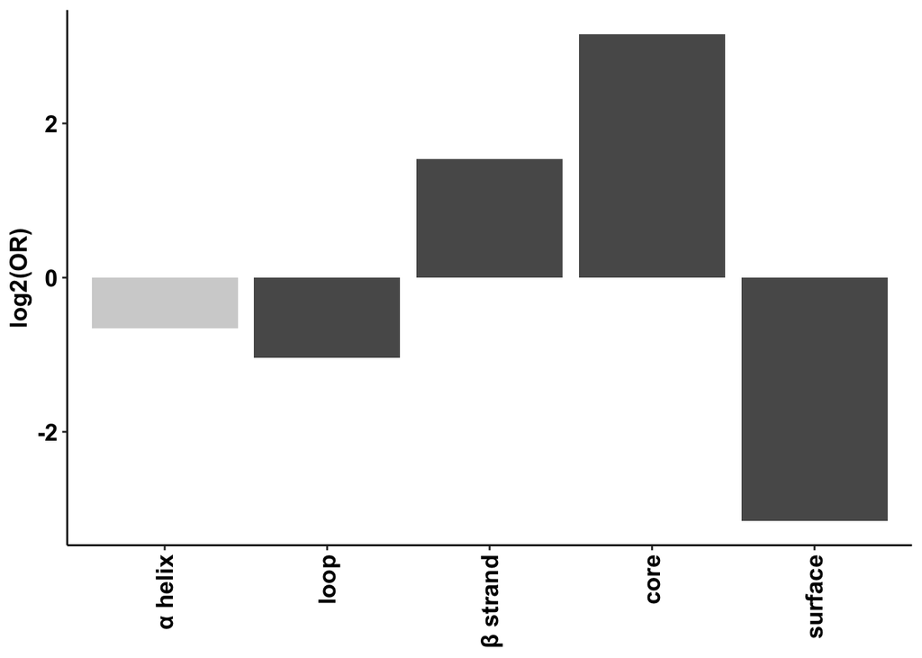

```r
enrichment_results_loop_beta_helix<-rbind(enrichment_results_loop_beta_helix, data.table(secondary_structure="core", odds_ratio=f_test1$estimate, p_value=f_test1$p.value, p_fdr_adj=NA))
enrichment_results_loop_beta_helix<-rbind(enrichment_results_loop_beta_helix, data.table(secondary_structure="surface", odds_ratio=f_test2$estimate, p_value=f_test2$p.value, p_fdr_adj=NA))


# Plot again the enrichments taking the libraries as a whole
ggplot(enrichment_results_loop_beta_helix)+
  geom_bar(aes(x=factor(secondary_structure, levels=c("helix", "loop", "sheet", "core", "surface"), labels=c("α helix", "loop", "β strand", "core", "surface")), y=log2(odds_ratio), alpha=p_value<0.05),stat="identity", position="dodge")+theme_classic()+scale_alpha_manual(values=c(0.3, 1))+
  scale_fill_brewer(palette="Set2")+
  theme(axis.title.x=element_blank(),
        axis.text.y=element_text(size=13),
        axis.title.y=element_text(size=15),
        axis.text.x=element_text(size=13, angle=90, vjust=0.5, hjust=1),
        legend.text = element_text(size=7))+ylab("log2(OR)")+
  labs(fill = "")+
  theme(axis.text.x=element_text(size=13,face="bold", color="black"),
        axis.text.y=element_text(size=13,face="bold", color="black"),
        axis.title.y=element_text(size=13,face="bold", color="black"),legend.position="none")
```

```r
ggsave(paste0("Figs/Fig4/Fig4Jenrichment_structures.pdf"), width=3, height=4)
```

Indeed 14 of the 16 most conserved allosteric hotspots are always classified as buried in the core in domains where they are classified as hotspots (OR=13.77, P<2.2x10-16), with the only exceptions being surface residues at positions 73 and 61 (Fig. 4h).

```r
# how many "outside BI" positions could be allosteric
length(unique(allo_hotspots_dt[binding_interface_contacts==F]$structural_alignment_pos))
```

```
## [1] 121
```

```r
# most conserved hotspots are always in the core (when hotspots)
allo_hotspots_dt_tmp[allo_consv_hotspot==T & allo_hotspot==T][order(structural_alignment_pos)]
```

```
##                library structural_alignment_pos allo_consv_hotspot allo_hotspot
##                 <char>                    <int>             <lgcl>       <lgcl>
##  1:   psd95_pdz3_cript                       14               TRUE         TRUE
##  2:   psd95_pdz2_cript                       14               TRUE         TRUE
##  3: psd95_pdz2_nmdar2a                       14               TRUE         TRUE
##  4: nherf3_pdz2_cep164                       14               TRUE         TRUE
##  5: psd95_pdz2_nmdar2a                       16               TRUE         TRUE
##  6: nherf3_pdz2_cep164                       16               TRUE         TRUE
##  7:  nherf3_pdz1_uhmk1                       16               TRUE         TRUE
##  8:   psd95_pdz3_cript                       31               TRUE         TRUE
##  9:   psd95_pdz2_cript                       31               TRUE         TRUE
## 10: psd95_pdz2_nmdar2a                       31               TRUE         TRUE
## 11:   erbin_pdz1_cript                       31               TRUE         TRUE
## 12:   psd95_pdz3_cript                       46               TRUE         TRUE
## 13:   psd95_pdz2_cript                       46               TRUE         TRUE
```

[output cut: 131 more lines]

```r
fisher.test(allo_hotspots_dt_tmp$core, allo_hotspots_dt_tmp$allo_consv_hotspot & allo_hotspots_dt_tmp$allo_hotspot, alternative = "greater")
```

```
##
##  Fisher's Exact Test for Count Data
##
## data:  allo_hotspots_dt_tmp$core and allo_hotspots_dt_tmp$allo_consv_hotspot & allo_hotspots_dt_tmp$allo_hotspot
## p-value < 2.2e-16
## alternative hypothesis: true odds ratio is greater than 1
## 95 percent confidence interval:
##  7.289451      Inf
## sample estimates:
## odds ratio
##    13.7707
```

Positions 73 and 61 are conserved hotspots, and are always in the surface, check the RSASA values

```r
allo_hotspots_dt_tmp[allo_consv_hotspot==T & allo_hotspot==T & structure_location=="surface"][order(structural_alignment_pos)]
```

```
##               library structural_alignment_pos allo_consv_hotspot allo_hotspot
##                <char>                    <int>             <lgcl>       <lgcl>
## 1:   psd95_pdz2_cript                       61               TRUE         TRUE
## 2: nherf3_pdz2_cep164                       61               TRUE         TRUE
## 3:  nherf3_pdz1_dap-1                       61               TRUE         TRUE
## 4:  nherf3_pdz1_uhmk1                       61               TRUE         TRUE
## 5:   psd95_pdz3_cript                       73               TRUE         TRUE
## 6: psd95_pdz2_nmdar2a                       73               TRUE         TRUE
## 7: nherf3_pdz2_cep164                       73               TRUE         TRUE
## 8:  nherf3_pdz1_dap-1                       73               TRUE         TRUE
## 9:  nherf3_pdz1_uhmk1                       73               TRUE         TRUE
##        rsasa structure_location   core
##        <num>             <char> <lgcl>
## 1: 0.6226030            surface  FALSE
## 2: 0.3572999            surface  FALSE
## 3: 0.4162505            surface  FALSE
## 4: 0.4162505            surface  FALSE
## 5: 0.4900788            surface  FALSE
## 6: 0.4495096            surface  FALSE
## 7: 0.5043719            surface  FALSE
## 8: 0.5453602            surface  FALSE
## 9: 0.5453602            surface  FALSE
```

Show the differential conservation of the core and surface quantitatively

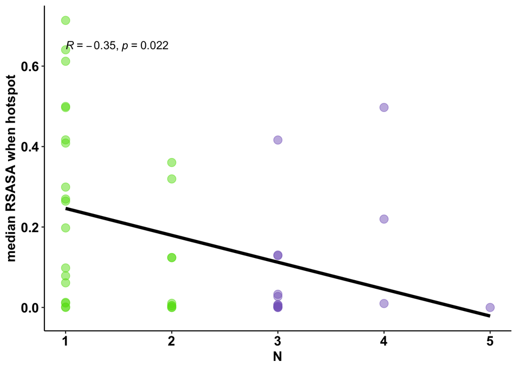

```r
conserved_hotspots_<-all_ddg_table_allo[allo_hotspot==T, .N, by = .(structural_alignment_pos, pdz, rsasa)][, .(N=.N, median_rsasa=median(rsasa),mean_rsasa=mean(rsasa)), by = .(structural_alignment_pos)]

ggplot(conserved_hotspots_, aes(x=N, y=median_rsasa))+
  geom_point(shape=21, alpha=0.5, size=3.5, aes(fill=N<3, color=N<3))+#,position = position_jitter(width = 0.1, height = 0))+
  #ylim(c(0,1))+
  theme_classic()+
  geom_smooth(method = "lm", color = "black", size=1.5, se=F) +
  stat_cor(method = "pearson", label.x = 1, label.y = 0.65)+
  ylab("median RSASA when hotspot")+
  scale_fill_manual(values=c("#886ac4", "#64dd17"))+
  scale_color_manual(values=c("#886ac4", "#64dd17"))+
  theme(axis.text.x=element_text(size=13,face="bold", color="black"),
        axis.text.y=element_text(size=13,face="bold", color="black"),
        axis.title.y=element_text(size=13,face="bold", color="black"),
        axis.title.x=element_text(size=13,face="bold", color="black"))+
  theme(legend.position="none")
```

```r
ggsave(paste0("Figs/Fig4/Fig4M_Hotspots_vs_rsasa.pdf"), width=4, height=4)
```

boxplots for the correlations of mutation effects in surface hotspots vs core hotspots

```r
all_ddg_table_allo_hotspots<-left_join(all_ddg_table, allo_hotspots_dt[assay=="binding", .(id, library, allo_hotspot,allo_consv_hotspot)])[assay=="binding"]
```

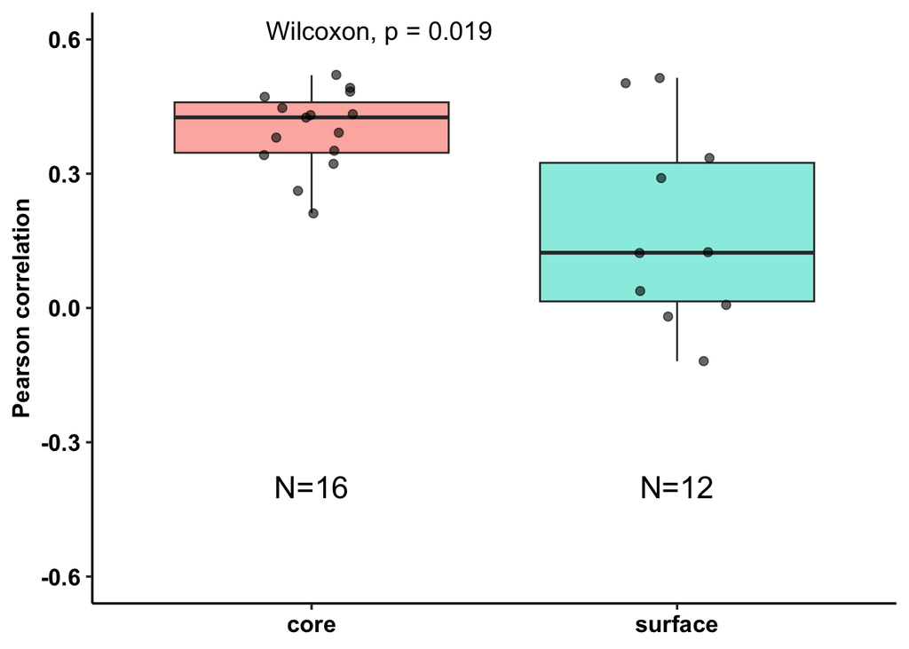

```r
# Keep only relevant columns, including the mutation identity
dt <- all_ddg_table_allo_hotspots[
  , .(library, structural_alignment_pos, Mut, ddg, allo_hotspot, structure_location)
]

lib_pairs <- combn(unique(dt$library), 2, simplify = FALSE)

calc_allo_corrs <- function(lib1, lib2, data) {
  d1 <- data[library == lib1]
  d2 <- data[library == lib2]

  # merge by position and mutation
  merged <- merge(d1, d2, by = c("structural_alignment_pos", "Mut"), suffixes = c("_1", "_2"))

  # sites that are allo_hotspot in ANY of the two libraries
    merged <- merged[allo_hotspot_1 & allo_hotspot_2]

  # subsets for surface vs core
  surf <- merged[structure_location_1 == "surface" & structure_location_2 == "surface"]
  core <- merged[structure_location_1 == "core"  & structure_location_2 == "core"]

  cor_surface <- if (nrow(surf) > 3)
    cor(surf$ddg_1, surf$ddg_2, use = "pairwise.complete.obs", method = "pearson") else NA_real_

  cor_core <- if (nrow(core) > 3)
    cor(core$ddg_1, core$ddg_2, use = "pairwise.complete.obs", method = "pearson") else NA_real_

  data.table(lib1 = lib1, lib2 = lib2,
             cor_surface = cor_surface,
             cor_core = cor_core,
             n_surface = nrow(surf),
             n_core = nrow(core))
}


results_list <- lapply(lib_pairs, \(pair) calc_allo_corrs(pair[1], pair[2], dt))
results_dt <- rbindlist(results_list, fill = TRUE)

results_long <- melt(results_dt,
                     id.vars = c("lib1", "lib2"),
                     measure.vars = c("cor_surface", "cor_core"),
                     variable.name = "region",
                     value.name = "correlation")[,
                     region := fifelse(region == "cor_surface", "surface", "core")]


results_long2 <- results_long[
  {
    pdz1 <- tstrsplit(lib1, "_")[[1]]
    pdz2 <- tstrsplit(lib2, "_")[[1]]
    dom1 <- paste(tstrsplit(lib1, "_")[[1]], tstrsplit(lib1, "_")[[2]], sep = "_")
    dom2 <- paste(tstrsplit(lib2, "_")[[1]], tstrsplit(lib2, "_")[[2]], sep = "_")
    dom1 != dom2
  }
]

# Split lib1 and lib2 into their components: gene, pdz, ligand
results_long2[, c("gene1", "pdz1", "ligand1") := tstrsplit(lib1, "_", fixed = TRUE)]
results_long2[, c("gene2", "pdz2", "ligand2") := tstrsplit(lib2, "_", fixed = TRUE)]

# Combine gene + pdz into a single PDZ identifier
results_long2[, PDZ1 := paste(gene1, pdz1, sep = "_")]
results_long2[, PDZ2 := paste(gene2, pdz2, sep = "_")]
results_long2[, class := "unrelated"]
results_long2[PDZ1==PDZ2, class := "same_pdz"]
results_long2[ligand1==ligand2, class := "same_ligand"]


library(ggplot2)
n_plot<-results_long2[!is.na(correlation) & class=="unrelated"][, .(.N) , by=.(region)]
ggplot(results_long2[!is.na(correlation) & class=="unrelated"], aes(x = region, y = correlation, fill = region)) +
  geom_boxplot(alpha = 0.6, outlier.shape = NA) +
  geom_jitter(width = 0.15, alpha = 0.6, size = 2) +
  theme_classic(base_size = 14) +
  labs(
    x = "Region",
    y = "Pearson correlation"
  ) +
  scale_fill_manual(values = c(core = "salmon", surface = "turquoise"))+
  stat_compare_means(size=5)+
  ylim(c(-0.6,0.6))+
  theme(legend.position="none")+
  theme(axis.text.x=element_text(size=13,face="bold", color="black"),
        axis.text.y=element_text(size=13,face="bold", color="black"),
        axis.title.y=element_text(size=13,face="bold", color="black"),
        axis.title.x=element_blank())+
  geom_text(data=n_plot, aes(y=-0.4, label=paste0( "N=",N)), size=6, color="black")
```

```r
ggsave(paste0("Figs/Fig4/FigS4M_hotspots_cor_surface_core.pdf"), width=4, height=4)
summary(results_long2[!is.na(correlation) & class=="unrelated" & region=="surface"]$correlation)
```

```
##     Min.  1st Qu.   Median     Mean  3rd Qu.     Max.
## -0.11896  0.03041  0.20729  0.26213  0.50570  0.71270
```

```r
summary(results_long2[!is.na(correlation) & class=="unrelated" & region=="core"]$correlation)
```

```
##    Min. 1st Qu.  Median    Mean 3rd Qu.    Max.
##  0.2117  0.3494  0.4282  0.4126  0.4749  0.6372
```

# hotspots are enriched in core and depleted in surface

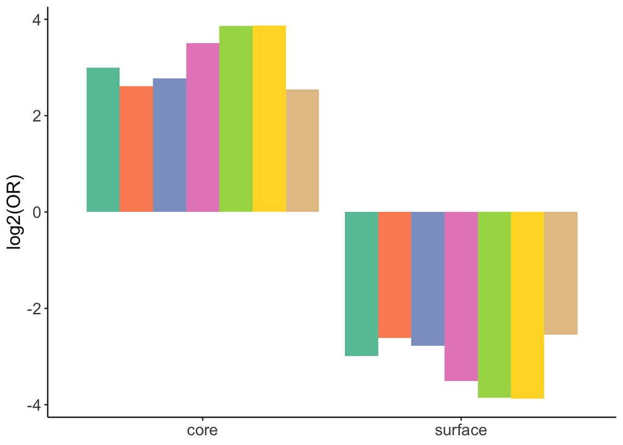

```r
# Order by library and structural position
allo_hotspots_dt_short<-allo_hotspots_dt[,.(allo_hotspot=allo_hotspot[1]), by=.(library, structural_alignment_pos, structure_location)]

# Function to compute enrichment
compute_enrichment <- function(dt) {
  result_list <- list()

  for (lib in unique(dt$library)) {
    lib_dt <- dt[library == lib]

    for (sec in unique(lib_dt$structure_location)) {
      in_block <- lib_dt[structure_location == sec]
      out_block <- lib_dt[structure_location != sec]

      # Construct contingency table
      mat <- matrix(
        c(sum(in_block$allo_hotspot),
          sum(!in_block$allo_hotspot),
          sum(out_block$allo_hotspot),
          sum(!out_block$allo_hotspot)),
        nrow = 2,
        byrow = TRUE
      )

      if(sec=="surface"){fisher_res <- fisher.test(mat, alternative="less")}
      if(sec=="core"){fisher_res <- fisher.test(mat, alternative="greater")}

      result_list[[paste(lib, sec, sep = "_")]] <- data.table(
        library = lib,
        structure_location = sec,
        odds_ratio = fisher_res$estimate,
        p_value = fisher_res$p.value
      )
    }
  }

  rbindlist(result_list)
}

enrichment_results <- compute_enrichment(allo_hotspots_dt_short)

enrichment_results$library_name<-gsub("_", "-", gsub(" binding ", " | ", (unlist(lapply(enrichment_results$library, lib_code_to_name, libraries, libraries_names)))))



ggplot(enrichment_results[order(library_name)])+geom_bar(aes(x=structure_location, y=log2(odds_ratio), alpha=p_value<0.05, fill=library_name), stat="identity", position="dodge")+theme_classic()+
  scale_alpha_manual(values=c( 1, 0.3))+
  scale_fill_brewer(palette="Set2")+
  theme(axis.title.x=element_blank(),
        axis.text.y=element_text(size=13),
        axis.title.y=element_text(size=15),
        axis.text.x=element_text(size=13),
        legend.position="none")+ylab("log2(OR)")+
  labs(fill = "")
```

```r
# median odds ratio for sheets
ggsave(paste0("Figs/Fig4/FigS4I.png"), width=2.5, height=3)
```

```r
enrichment_results
```

```
##                library structure_location  odds_ratio      p_value
##                 <char>             <char>       <num>        <num>
##  1:   psd95_pdz3_cript            surface  0.17136923 9.676524e-03
##  2:   psd95_pdz3_cript               core  5.83535328 9.676524e-03
##  3:   psd95_pdz2_cript            surface  0.06896213 8.740635e-05
##  4:   psd95_pdz2_cript               core 14.50071201 8.740635e-05
##  5: psd95_pdz2_nmdar2a            surface  0.06826965 9.544646e-06
##  6: psd95_pdz2_nmdar2a               core 14.64779672 9.544646e-06
##  7: nherf3_pdz2_cep164            surface  0.08802813 1.253296e-05
##  8: nherf3_pdz2_cep164               core 11.36000535 1.253296e-05
##  9:  nherf3_pdz1_dap-1            surface  0.16343937 7.531085e-04
## 10:  nherf3_pdz1_dap-1               core  6.11847684 7.531085e-04
## 11:  nherf3_pdz1_uhmk1            surface  0.14610816 7.484628e-04
## 12:  nherf3_pdz1_uhmk1               core  6.84424454 7.484628e-04
## 13:   erbin_pdz1_cript            surface  0.12563711 1.243975e-03
```

[output cut: 17 more lines]

# conservation in sequence and structure

The most functionally conserved allosteric hotspots are also more conserved in sequence and structure.

## conservation in sequence

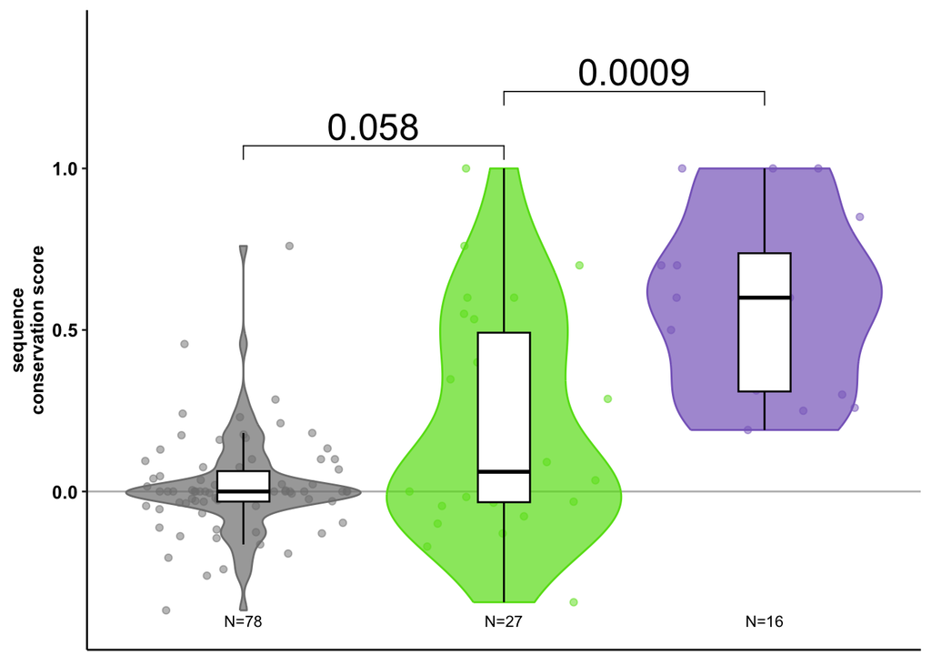

```r
# defining hotspot types
allo_hotspots_dt[,hotspot_type:="non-Hotspot"]
allo_hotspots_dt[structural_alignment_pos %in% conserved_hotspots$structural_alignment_pos & allo_hotspot, hotspot_type:="conserved"]
allo_hotspots_dt[!structural_alignment_pos %in% conserved_hotspots$structural_alignment_pos & allo_hotspot, hotspot_type:="variable"]

categories<-c("non-Hotspot", "variable", "conserved")
categories_names<-c("non-Hotspot", "Hotspot in\n1 or 2 PDZs", "Hotspots\nin >2/5 PDZs")
allo_hotspots_dt_short<-allo_hotspots_dt[,.(hotspot_type=hotspot_type[1], consv=consv[1]), by=.(library, structural_alignment_pos, secondary_structure)]

allo_hotspots_dt_short_short<-allo_hotspots_dt_short[,.(hotspot_type=paste0(unique(hotspot_type), collapse=","), consv=consv[1]), by=.(structural_alignment_pos)]
allo_hotspots_dt_short_short[hotspot_type=="non-Hotspot", hotspot_type_plot:="non-Hotspot"]
allo_hotspots_dt_short_short[grepl("conserved", hotspot_type)==T, hotspot_type_plot:="conserved"]
allo_hotspots_dt_short_short[grepl("variable", hotspot_type)==T, hotspot_type_plot:="variable"]


n_plot<-allo_hotspots_dt_short_short[, .(.N) , by=.(hotspot_type_plot)]
ggplot(allo_hotspots_dt_short_short, aes(x=factor(hotspot_type_plot, levels=categories, labels=categories_names), y=consv, fill=hotspot_type_plot, color=hotspot_type_plot))+
  geom_hline(aes(yintercept = 0), color="grey")+
  geom_violin(alpha=0.7, scale="width")+
  geom_point(position="jitter", alpha=0.5)+
  geom_boxplot(alpha=1, width=0.2, color="black", fill="white", outliers=F)+
  theme_classic()+
  stat_compare_means(comparisons=list(c("non-Hotspot", "Hotspot in\n1 or 2 PDZs"), c("Hotspot in\n1 or 2 PDZs", "Hotspots\nin >2/5 PDZs")), size=7, aes(label=after_stat(p)))+
  scale_fill_manual("",values=c(  "#886ac4","grey50", "#64dd17"))+
  scale_color_manual("",values=c(  "#886ac4","grey50", "#64dd17"))+
  theme(legend.position="none",
        axis.title.x=element_blank(),
        axis.text.x=element_blank(),
        axis.ticks.x=element_blank())+
  ylab("sequence\nconservation score")+
  ylim(c(-0.4, 1.4))+
  theme(axis.text.y=element_text(size=10,face="bold", color="black"),
         axis.title.y=element_text(size=10,face="bold", color="black"))+
  geom_text(data=n_plot, aes(y=-0.4, label=paste0("N=", N)), size=3, color="black")
```

```r
ggsave(paste0("Figs/Fig4/Fig4Nsequence_conservation.pdf"), width=2, height=2.3)
```

## conservation in structure

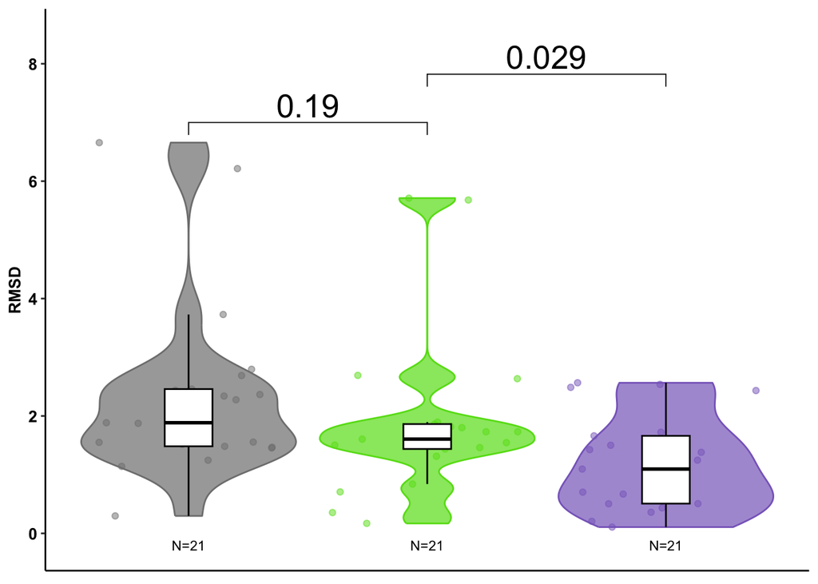

```r
###### load models ######
library(bio3d)
pdb_dir<-"data/structures/superimposed/"
model1 <- read.pdb(paste0(pdb_dir, "superimposed_dlg4_pdz3_cript.pdb.pdb"))
model2 <- read.pdb(paste0(pdb_dir, "superimposed_dlg4_pdz2_cript.pdb.pdb"))
model3 <- read.pdb(paste0(pdb_dir, "superimposed_dlg4_pdz2_nmdar2a.pdb.pdb"))
model4 <- read.pdb(paste0(pdb_dir, "superimposed_nhrf3_pdz2_cep164.pdb.pdb"))
model5 <- read.pdb(paste0(pdb_dir, "superimposed_nhrf3_pdz1_dlgap.pdb.pdb"))
model6 <- read.pdb(paste0(pdb_dir, "superimposed_nhrf3_pdz1_uhmk1.pdb.pdb"))
model7 <- read.pdb(paste0(pdb_dir, "superimposed_erbin_pdz1_cript.pdb.pdb"))
models<-list(model1, model2, model3, model4, model5, model6, model7)


###### function ######
#define the function that will compute the local rmsd (actually local euclidean distances)
calculate_local_rmsd <- function(model1, model2, pair) {
  index1<-model1$atom$resno==pair[1] &  model1$atom$elety=="CA" & model1$atom$chain=="A"
  index2<-model2$atom$resno==pair[2] &  model2$atom$elety=="CA" & model2$atom$chain=="A"
  coord1 <- c(model1$atom$x[index1], model1$atom$y[index1], model1$atom$z[index1])
  coord2 <- c(model2$atom$x[index2], model2$atom$y[index2], model2$atom$z[index2])
   # Euclidean distance (squared differences summed)
  rmsd <- sqrt(sum((coord1 - coord2)^2))   # Root Mean Square Deviation
  return(rmsd)
}


###### iterate ######
combinations<-t(combn(1:7, 2))
rmsd_comparisons<-data.table()
for(i in 1:nrow(combinations)){
  pair<-combinations[i,]
  libraries_<-libraries_binding_names[pair]
  model1<-models[pair[1]]
  model2<-models[pair[2]]

  lib1<-libraries_binding_names[pair[1]]
  lib2<-libraries_binding_names[pair[2]]

  #paired positions
  paired_dt<-t(reshape(allo_hotspots_dt[library %in% libraries_, c("structural_alignment_pos", "Pos", "library")], timevar="structural_alignment_pos", idvar="library", direction="wide"))
  aln_positions<-as.numeric(lapply(strsplit(rownames(paired_dt[-1,]), "[.]"), "[[", 2))
  paired_dt<-data.table(paired_dt[-1,])
  paired_dt$structural_alignment_pos<-aln_positions
  paired_dt <- na.omit(paired_dt)

  for(b_a_p in paired_dt$structural_alignment_pos){
    positions<-as.numeric(c(paired_dt[structural_alignment_pos==b_a_p]$V1,paired_dt[structural_alignment_pos==b_a_p]$V2))
    local_rmsd <- calculate_local_rmsd(model1[[1]], model2[[1]], positions)
    rmsd_comparisons<-rbind(rmsd_comparisons, data.table(paste0(pair, collapse="-"), paste0(lib1,"-",lib2), local_rmsd, b_a_p))


  }

}

##### annotate #####
rmsd_comparisons_studyBI<-rmsd_comparisons
rmsd_comparisons_studyBI$lib1<-unlist(lapply(strsplit(rmsd_comparisons_studyBI$V2, "-"), "[[", 1))
rmsd_comparisons_studyBI$lib2<-unlist(lapply(strsplit(rmsd_comparisons_studyBI$V2, "-"), "[[", 2))

rmsd_comparisons_studyBI[, same_pdz:=sub("^(([^_]+)_([^_]+))_.*", "\\1", lib1)==sub("^(([^_]+)_([^_]+))_.*", "\\1", lib2)]
rmsd_comparisons_studyBI[, same_lig:=sub("^[^_]+_[^_]+_", "", lib1)==sub("^[^_]+_[^_]+_", "", lib2)]
rmsd_comparisons_studyBI[,class2:=sub("^[^_]+_[^_]+_", "", lib1)=="cep164" | sub("^[^_]+_[^_]+_", "", lib2)=="cep164"]
rmsd_comparisons_studyBI[,binding_interafce:=b_a_p %in% core_bi]
rmsd_comparisons_studyBI[same_pdz==T, comparison_class:="same_pdz"]
rmsd_comparisons_studyBI[same_lig==T, comparison_class:="same_lig"]
rmsd_comparisons_studyBI[is.na(comparison_class), comparison_class:="unrelated"]


unique_non_hotspots_pos<-unique(allo_hotspots_dt[hotspot_type=="non-Hotspot"]$structural_alignment_pos)
rmsd_comparisons_studyBI[b_a_p %in% unique_non_hotspots_pos, class:="non_hotspot"]
rmsd_comparisons_studyBI[b_a_p %in% conserved_hotspots$structural_alignment_pos, class:="conserved_hotspot"]
unique_variable_hotspots_pos<-unique(allo_hotspots_dt[hotspot_type=="variable"]$structural_alignment_pos)
rmsd_comparisons_studyBI[b_a_p %in% unique_variable_hotspots_pos, class:="variable_hotspot"]


## calculate rmsd of the whole group of residues in each category per pairwise comparison ###
# Join and calculate rmsd of all the residues in each category for each comparison
rmsd_results <- rmsd_comparisons_studyBI[, .(
  rmsd_conserved_hotspot = if (.N > 0) sqrt(mean((local_rmsd[class == "conserved_hotspot"])^2)) else NA_real_,
  rmsd_variable_hotspot = if (.N > 0) sqrt(mean((local_rmsd[class == "variable_hotspot"])^2)) else NA_real_,
  rmsd_other = if (.N > 0) sqrt(mean((local_rmsd[class == "non_hotspot"])^2)) else NA_real_
), by = .(V1, V2, lib1, lib2, comparison_class)]

rmsd_results<-melt(rmsd_results, id.vars = c( "V1", "V2", "lib1", "lib2", "comparison_class"))
categories<-c("rmsd_other", "rmsd_variable_hotspot", "rmsd_conserved_hotspot")
categories_names<-c("non-Hotspot", "Hotspot in\n1 or 2 PDZs", "Hotspots\nin >2/5 PDZs")

n_plot<-rmsd_results[, .(.N) , by=.(variable)]
ggplot(rmsd_results, aes(x=factor(variable, levels=categories, labels=categories_names), y=value, fill=variable, color=variable))+
  geom_violin(scale="width", alpha=0.7)+
   geom_point(position="jitter", alpha=0.5)+
  geom_boxplot(alpha=1, width=0.2, color="black", fill="white", outliers=F)+
  scale_color_manual("",values=c( "#886ac4","#64dd17","grey50"))+
  scale_fill_manual("",values=c("#886ac4", "#64dd17","grey50"))+
  stat_compare_means(comparisons=list(c("non-Hotspot", "Hotspot in\n1 or 2 PDZs"), c("Hotspot in\n1 or 2 PDZs", "Hotspots\nin >2/5 PDZs")), size=7, aes(label=after_stat(p)))+
  theme_classic()+theme(legend.position="none",
                        axis.title.x=element_blank(),
                        axis.text.x=element_blank(),
                        axis.ticks.x=element_blank())+
  ylim(c(-0.2,8.5))+ylab("RMSD")+
  theme(axis.text.y=element_text(size=10,face="bold", color="black"),
         axis.title.y=element_text(size=10,face="bold", color="black"))+
  geom_text(data=n_plot, aes(y=-0.2, label=paste0( "N=",N)), size=3, color="black")
```

```r
ggsave(paste0("Figs/Fig4/Fig4Ostructure_conservation.pdf"), width=1.7, height=2.2)
```

## RSASA violin plots

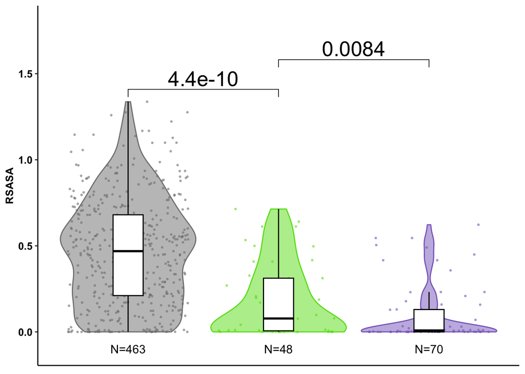

```r
# definiing hotspot types
allo_hotspots_dt[,hotspot_type:="non-Hotspot"]
allo_hotspots_dt[structural_alignment_pos %in% conserved_hotspots$structural_alignment_pos & allo_hotspot, hotspot_type:="conserved"]
allo_hotspots_dt[!structural_alignment_pos %in% conserved_hotspots$structural_alignment_pos & allo_hotspot, hotspot_type:="variable"]

categories<-c("non-Hotspot", "variable", "conserved")
categories_names<-c("non-Hotspot", "Hotspot in\n1 or 2 PDZs", "Hotspots\nin >2/5 PDZs")
allo_hotspots_dt_short<-allo_hotspots_dt[,.(hotspot_type=hotspot_type[1], consv=consv[1]), by=.(library, structural_alignment_pos, rsasa)]

allo_hotspots_dt_short[hotspot_type=="non-Hotspot", hotspot_type_plot:="non-Hotspot"]
allo_hotspots_dt_short[grepl("conserved", hotspot_type)==T, hotspot_type_plot:="conserved"]
allo_hotspots_dt_short[grepl("variable", hotspot_type)==T, hotspot_type_plot:="variable"]

n_plot<-allo_hotspots_dt_short[, .(.N) , by=.(hotspot_type_plot)]
ggplot(allo_hotspots_dt_short, aes(x=factor(hotspot_type_plot, levels=categories, labels=categories_names), y=rsasa, fill=hotspot_type_plot, color=hotspot_type_plot))+
  geom_violin(alpha=0.5, scale="width")+
  geom_point(position="jitter", alpha=0.5, size=0.5)+
  geom_boxplot(alpha=1, width=0.2, color="black", fill="white", outliers=F)+
  theme_classic()+
  stat_compare_means(comparisons=list(c("non-Hotspot", "Hotspot in\n1 or 2 PDZs"), c("Hotspot in\n1 or 2 PDZs", "Hotspots\nin >2/5 PDZs")), size=7, aes(label=after_stat(p)), method="wilcox.test")+
  scale_fill_manual("",values=c(  "#886ac4","grey50", "#64dd17"))+
  scale_color_manual("",values=c(  "#886ac4","grey50", "#64dd17"))+
  theme(legend.position="none",
        axis.title.x=element_blank(),
        axis.text.x=element_blank(),
        axis.ticks.x=element_blank())+
  ylab("RSASA")+
  ylim(c(-0.1, 1.8))+
  theme(axis.text.y=element_text(size=10,face="bold", color="black"),
         axis.title.y=element_text(size=10,face="bold", color="black"))+
  geom_text(data=n_plot, aes(y=-0.1, label=paste0("N=", N)), size=4, color="black")
```

```r
ggsave(paste0("Figs/Fig4/Fig4Krsasa_allo_hotspots.pdf"), width=1.7, height=2.2)
```

# allosteric innovation in a protein family

In addition to the functionally conserved hotspots, for each interaction there is a median of seven additional hotspots only present in one or two PDZ domains.

```r
# Beyond the conserved allosteric hotspots, all PDZ-ligand interactions contain at least two additional allosteric hotspots

allo_hotspots_dt_variable<-allo_hotspots_dt[allo_hotspot==T & !structural_alignment_pos %in% conserved_hotspots$structural_alignment_pos]
allo_hotspots_dt_variable_<-allo_hotspots_dt_variable[,.(allo_hotspot=allo_hotspot[1]), by=.(library, structural_alignment_pos)]
allo_hotspots_dt_variable_counts_per_lib<-allo_hotspots_dt_variable_[,.(N=.N), by=.(library)]
summary(allo_hotspots_dt_variable_counts_per_lib$N)
```

```
##    Min. 1st Qu.  Median    Mean 3rd Qu.    Max.
##   4.000   5.000   7.000   6.857   8.500  10.000
```

how many conserved we have per interaction

```r
# Beyond the conserved allosteric hotspots, all PDZ-ligand interactions contain at least two additional allosteric hotspots

allo_hotspots_dt_conserved<-allo_hotspots_dt[allo_hotspot==T & structural_alignment_pos %in% conserved_hotspots$structural_alignment_pos]
allo_hotspots_dt_conserved_<-allo_hotspots_dt_conserved[,.(allo_hotspot=allo_hotspot[1]), by=.(library, structural_alignment_pos)]
allo_hotspots_dt_conserved_counts_per_lib<-allo_hotspots_dt_conserved_[,.(N=.N), by=.(library)]
summary(allo_hotspots_dt_conserved_counts_per_lib$N)
```

```
##    Min. 1st Qu.  Median    Mean 3rd Qu.    Max.
##     5.0     9.0    10.0    10.0    11.5    14.0
```

# conserved allosteric effects in variable hotspots (SAME PDZ)

PSD95_PDZ2

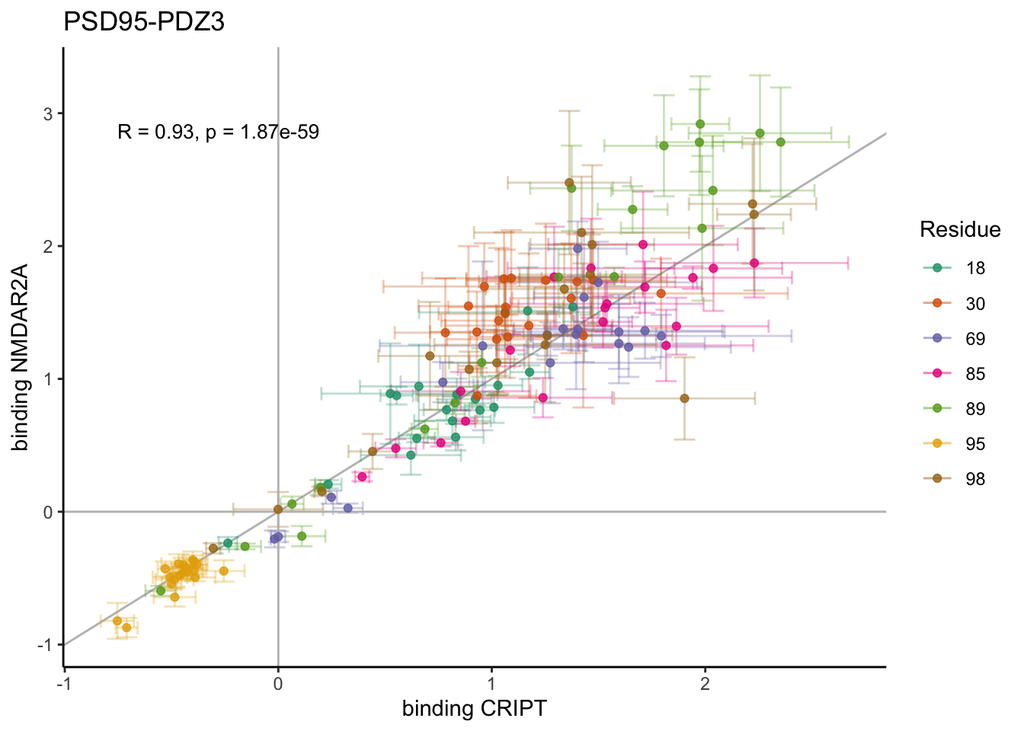

```r
#PSD95_PDZ2==DLG4_PDZ2
allo_hotspots_dt_762<-allo_hotspots_dt[pdz_name=="PSD95_PDZ2"]

#POSITIONS that are hotspots in at least one of them
hotspot_variable_positions_762<-unique(allo_hotspots_dt_762[allo_hotspot==T & allo_consv_hotspot==F]$structural_alignment_pos)

# get all the dataset for these
all_ddg_table[, mut:=substr(id, nchar(id), nchar(id))]
allo_hotspots_dt_762_variableH<-all_ddg_table[pdz=="psd95_pdz2" & assay=="binding" & structural_alignment_pos %in% hotspot_variable_positions_762]


allo_hotspots_dt_762_variableH<-reshape(allo_hotspots_dt_762_variableH[,.(structural_alignment_pos, mut, library, ddg, std_ddg)], idvar = c("structural_alignment_pos", "mut"), timevar = "library", direction = "wide")

# compare at the level of mutations
correlation_762_mutation<-cor(allo_hotspots_dt_762_variableH[,-c("structural_alignment_pos", "mut")])[1,2]


cor_res <- cor.test(
  allo_hotspots_dt_762_variableH$ddg.psd95_pdz2_cript,
  allo_hotspots_dt_762_variableH$ddg.psd95_pdz2_nmdar2a,
  use = "complete.obs",
  method = "pearson"
)

R_val <- unname(cor_res$estimate)
p_val <- cor_res$p.value
label_text <- sprintf("R = %.2f, p = %.2e", R_val, p_val)


ggplot(allo_hotspots_dt_762_variableH, aes(x=ddg.psd95_pdz2_cript, y=ddg.psd95_pdz2_nmdar2a, color=factor(structural_alignment_pos)))+
  scale_color_brewer(palette="Dark2")+
  geom_abline(color="grey")+
  geom_errorbar(aes(xmin = ddg.psd95_pdz2_cript - std_ddg.psd95_pdz2_cript, xmax = ddg.psd95_pdz2_cript + std_ddg.psd95_pdz2_cript), width = 0.1, alpha = 0.3) +
  geom_errorbar(aes(ymin = ddg.psd95_pdz2_nmdar2a - std_ddg.psd95_pdz2_nmdar2a, ymax = ddg.psd95_pdz2_nmdar2a + std_ddg.psd95_pdz2_nmdar2a), width = 0.1, alpha = 0.3) +
  geom_hline(color="grey", aes(yintercept = 0))+
  geom_vline(color="grey", aes(xintercept = 0))+
  geom_point(alpha=0.8, size=1.5)+theme_classic()+
  labs(color="Residue")+
  ylab(libraries_binding_names[3])+
  xlab(libraries_binding_names[2])+
  ggtitle("PSD95-PDZ3")+
  xlab("binding CRIPT")+
  ylab("binding NMDAR2A")+
  annotate("text",
         x = min(allo_hotspots_dt_762_variableH$ddg.psd95_pdz2_cript, na.rm = TRUE),
         y = max(allo_hotspots_dt_762_variableH$ddg.psd95_pdz2_nmdar2a, na.rm = TRUE),
         hjust = 0,
         vjust = 1,
         label = label_text,
         size = 3.5)
```

```r
ggsave(paste0("Figs/Fig4/FigS4Jscatter_variable_762.png"), width=3, height=3)
```

NHERF3_PDZ1

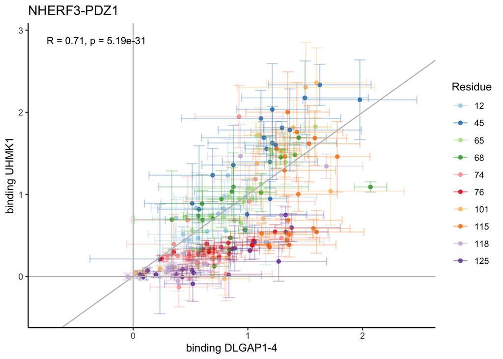

```r
allo_hotspots_dt_771<-allo_hotspots_dt[pdz_name=="NHERF3_PDZ1"]
#positions that are hotspots in at least one of them
hotspot_positions_771<-unique(allo_hotspots_dt_771[allo_hotspot==T & !structural_alignment_pos %in% conserved_hotspots$structural_alignment_pos]$structural_alignment_pos)

# get all the dataset for these
allo_hotspots_dt_771_variableH<-all_ddg_table[pdz=="nherf3_pdz1" & assay=="binding" & structural_alignment_pos %in% hotspot_positions_771]
allo_hotspots_dt_771_variableH$library<-gsub("-", "_",allo_hotspots_dt_771_variableH$library )

allo_hotspots_dt_771_variableH<-reshape(allo_hotspots_dt_771_variableH[,.(structural_alignment_pos, mut, std_ddg, library, ddg)], idvar = c("structural_alignment_pos", "mut"), timevar = "library", direction = "wide")

cor_res <- cor.test(
  allo_hotspots_dt_771_variableH$ddg.nherf3_pdz1_dap_1,
  allo_hotspots_dt_771_variableH$ddg.nherf3_pdz1_uhmk1,
  use = "complete.obs",
  method = "pearson"
)

R_val <- unname(cor_res$estimate)
p_val <- cor_res$p.value
label_text <- sprintf("R = %.2f, p = %.2e", R_val, p_val)


# compare at the level of mutations
correlation_771_mutation<-cor(allo_hotspots_dt_771_variableH[,-c("structural_alignment_pos", "mut")])[1,2]
ggplot(allo_hotspots_dt_771_variableH, aes(x=ddg.nherf3_pdz1_dap_1, y=ddg.nherf3_pdz1_uhmk1, color=factor(structural_alignment_pos)))+
  scale_color_brewer(palette="Paired")+
  geom_point(alpha=0.8, size=1.5)+theme_classic()+
  geom_errorbar(aes(xmin = ddg.nherf3_pdz1_dap_1 - std_ddg.nherf3_pdz1_dap_1, xmax = ddg.nherf3_pdz1_dap_1 + std_ddg.nherf3_pdz1_dap_1), width = 0.1, alpha = 0.3) +
  geom_errorbar(aes(ymin = ddg.nherf3_pdz1_uhmk1 - std_ddg.nherf3_pdz1_uhmk1, ymax = ddg.nherf3_pdz1_uhmk1+ std_ddg.nherf3_pdz1_uhmk1), width = 0.1, alpha = 0.3) +
  geom_abline(color="grey")+
  geom_hline(color="grey", aes(yintercept = 0))+
  geom_vline(color="grey", aes(xintercept = 0))+
  labs(color="Residue")+
  ylab(libraries_binding_names[6])+
  xlab(libraries_binding_names[5])+
  #stat_cor(aes(color="black"), color="black", show.legend = F)+
  ggtitle("NHERF3-PDZ1")+
  xlab("binding DLGAP1-4")+
  ylab("binding UHMK1")+
  annotate("text",
         x = min(allo_hotspots_dt_762_variableH$ddg.psd95_pdz2_cript, na.rm = TRUE),
         y = max(allo_hotspots_dt_762_variableH$ddg.psd95_pdz2_nmdar2a, na.rm = TRUE),
         hjust = 0,
         vjust = 1,
         label = label_text,
         size = 3.5)
```